# Zupfnoter-Handbuch

www.zupfnoter.de

# 1 Über dieses Handbuch

Du siehst dieses Handbuch und bist schockiert, dass es über 50 Seiten hat. Aber wie sagt man doch so schön: “keine Panik!”. Ersteller einfacher Unterlegnoten kommen mit den ersten Kapiteln schon auf die Erfolgsstraße.

Dieses Handbuch richtet sich an alle, die Zupfnoter vewenden und sich selbst in den Zupfnoter einarbeiten wollen. Dabei haben wir folgende Zielgruppen im Blick:

- **Ersteller einfacher Unterlegnoten**: Der Einsteiger erstellt Musikstücke mit einer Stimme und ggf. Texten. Hierzu gehört auch der Import vorhandener Stücke über die Dateiformate MusicXml (.xml, .mxl) oder ABC-Notation (.abc).
- **Ersteller anspruchsvoller Unterlegnoten**: Der Experte erstellt komplexe Musikstücke mit vielen Stimmen, detaillierter Anordnung, mehreren Auszügen, Transponierungen usw. Diese Zielgruppe nutzt mehr und mehr die vielfältigen Möglichkeiten von Zupfnoter und ist im Wesentlichen durch die Größe des Instrumentes und die eigene Phantasie begrenzt.
- **Lektoren** schreiben nicht selbst im Zupfnoter, sondern redigieren Noten in Zpufnoter.

Dieses Handbuch wurde von Verena Hinzmann und Bernhard Weichel erstellt.

> **Hinweis**: Dieses Handbuch ist noch nicht fertig; Kapitel 5 ff. sind nur rudimentär. Wir veröffentlichen daher die Voreabversionen mit TODOs und Zeilennummern.

> Für Hinweise auf Fehler oder Verbessrungsmöglichkeiten sind wir sehr dankbar.

TODO: markieren, für welche Zielgruppe welche Textabschnitte relevant sind.

TODO: Screenshots aktualisieren

# 2 Einführung

Zupfnoter ist ein freies Programm, um selbst Unterlegnoten für Tischharfen zu erstellen. Die mit Zupfnoter erstellten Unterlegnoten eignen sich für alle gängigen Tischharfen (Zauberharfe, Veeh-Harfe®, Tischharfen von “Instrumentenbau Franz Bauer“). Somit kannst du alles auf deiner Tischharfe spielen, was du willst.

Zupfnoter ist so flexibel, dass man Noten für alle chromatischen Instrumente erstellen kann, die von oben nach unten gespielt werden, egal welche Form, wieviele Saiten und welchen Saitenabstand sie haben. Insbesondere kann der Saitenabstand individuell eingestellt werden, so dass Zupfnoter auch für Instumente mit einem Saitenabstand ungleich 11,5 mm geeignet ist.

Der Zupfnoter wird über die Homepage https://www.zupfnoter.de aufgerufen und kann ohne die Installation einer Software auf deinem PC sofort angewendet werden. Er läuft unabhängig vom Betriebssystem des PC’s und ist für Mac, Linux und sogar für Windows geeignet.

Zupfnoter unterstützt vier grundlegende Schritte zur Erstellung von Unterlegnoten:

- **Noten eingeben**

  Zupfnoter erfasst die Musikstücke[^1] in der Standard-ABC-Notation. Diese kann man selbst eingeben oder vorhandene ABC-Dateien verwenden.

  Über die Music-XML-Schnittstelle können Noten aus vielen Musik-Programmen importiert werden (z.B. aus dem ebenfalls freien Programm Musescore).
- **Prüfen**

  Zupfnoter stellt die Musikstücke in ABC-Notation, in regulären Noten und auch als Unterlegnotenvorschau auf dem Bildschirm dar.

  Zupfnoter spielt die Musikstücke auch ab und zeigt während des Abspielens den Ablauf in den beiden Notenansichten an. Die eingegebenen Noten können so einfach überprüft und korrigiert werden.

  Taktfehler können in den regulären Noten leicht erkannt werden.
- **Gestalten**

  Zupfnoter setzt die Unterlegnoten für die Tischharfe automatisch. Man hat dabei sehr flexible Gestaltungsmöglichkeiten und kann einzelne Stimmen beliebig für die Ausgabe zusammenstellen (Auszüge).

  Für die Stimmen gibt es wählbare Dekorationen wie Melodielinien, Zählmarken, Synchronisationslinien. Sogar die Größe der Noten ist einstellbar.
- **Drucken**

  Zupfnoter erstellt PDF-Dateien im Format A3 oder A4, die direkt ausgedruckt werden können.

  Bei Ausgabe im DIN-A4-Format teilt Zupfnoter das Notenblatt auf drei Seiten auf. Anhand der aufgedruckten Schnittmarken kann anschließend das Notenblatt geschnitten und zusammengefügt werden.

  Als Web-Anwendung speichert Zupfnoter die erstellten Musikstücke per Download auf dem lokalen Rechner oder in der Cloud (Dropbox).

# 3 Erste Schritte mit Zupfnoter

Mit dem Zupfnoter kannst du ganz schnell einfache Musikstücke eingeben und als Unterlegnoten darstellen. Mit der Zeit wirst du immer mehr Funktionen und Möglichkeiten von Zufnoter erobern, um auch komplexe Musikstücke zu bearbeiten bzw. die Unterlegnoten im Detail nach deinen Wünschen zu gestalten.

## 3.1 Zupfnoter starten

Starte nun Zupfnoter in folgenden Schritten:

1. öffne deinen Web-Browser (vorzugsweise Chrome)
2. gehe zu “https://www.zupfnoter.de”
3. drücke auf die Schaltfläche “Zupfnoter Starten”

[figure not shown]

   Hinweis: Wer lieber erst die Einführungsvideos anschaut, kann natürlich auch auf die Schaltfläche “Tutorials” klicken :-).

Beim ersten Aufruf des Zupfnoter erscheint ein beispielhaftes Musikstück. Mit diesem Beispiel kannst du in die Grundlagen des Zupfnoters einsteigen.

Anhand der schriftlichen Anleitungen unter dem Hilfemenü und mit den mündlichen Unterweisungen in den Tutorial-Videos (Selbstlerneinheiten) lassen sich gut die einzelnen Schritte für die Erstellung “Alle meine Entchen” nachvollziehen.

## 3.2 Dein erstes Musikstück eingeben

Zupfnoter erfasst das Musikstück in der so genannten ABC-Notation. Diese wurde (unabhängig von Zupfnoter) erfunden, um Musikstücke auf Computern verarbeiten zu können. Computer können die ABC-Notation interpretieren, um daraus herkömmliche Musiknoten zu generieren oder auch Musikstücke auf dem Computer abspielen zu können. Unter dem Hilfemenü des Zupfnoters findet man eine deutsche Anleitung für die ABC-Notation.

1. klicke auf Schaltfläche “Neu”, es erscheint ein Eingabeformular
2. gib die Liednummer (X:) und den Titel in das ein (z.B.; X: “1”, Titel: “Alle meine Entchen”) und bestätige mit der Schaltfläche “Ok”.

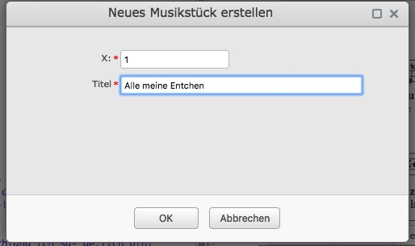

   Im linken Fenster erscheint die Nummer in Zeile 1 und der Titel in Zeile 3. Zeile 2 zeigt den Dateinamen den Zupfnoter aus Nummer und Titel gebildet hat.

   > **Hinweis**: Der Wert von `X:` (Liednummer) muss eine positive Ganzzahl sein. Es dürfen keine Buchstaben, Leerzeichen oder Unterstriche enthalten sein.
3. klicke im linken Fenster in Zeile 12
4. gib die folgenden Notennamen und Notenwerte ein:

   `CDEF | G2G2 | AAAA | G4 | AAAA | G4 | FFFF | E2E2 | GGGG | C4 |]`

   Da du zunächst nur eine Stimme eingegeben hast, kannst du in Zeile 10 die “2” am Ende löschen. Dann wird nur die erste Stimme dargestellt.
5. klicke auf Schaltfläche “Rendern”, um die Unterlegnoten zu erzeugen und die Meldungen im linken Fenster zu aktualisieren.
6. im Fenster rechts unten siehst du nun eine Vorschau der Unterlegnoten:

[figure not shown]

**Herzlichen Glückwunsch!** Du hast dein erstes Musikstück mit Zupfnoter erstellt.

> **Hinweis:** Um Taktstriche (“**`|`**”), Wiederholungszeichen (“**`|: :|`**”) und Schlussstriche (“**`]`**”) darstellen zu können, benötigt man folgende Tastenkombinationen zur Erstellung des senkrechten Striches (vertical bar) bzw. der eckigen Klammer:

> siehe auch http://www.die-tastenkombination.de/

> **Windows**
> - `|` erzeugt man mit der Taste AltGr und der Taste links vom Y
> - `[` erzeugt man mit der Taste `AltGr` und der Taste `8`
> - `]` erzeugt man mit der Taste `AltGr` und der Taste `9`
> - `~` erzeugt man mit der Taste `AltGr` der Taste `+`
> - `©` erzeugt man mit der Taste `Alt`und der Tastefolge 069 auf dem Ziffernblock

> **Mac**
> - `|` erzeugt man mit der Taste `Alt` und der Taste `7`
> - `[` erzeugt man mit der Taste `Alt` und der Taste `5`
> - `]` erzeugt man mit der Taste `Alt` und der Taste `6`
> - `~` erzeugt man mit der Taste `Alt` der Taste `n`
> - `©` erzeugt man mit der Taste `Alt`und der Taste `G`

## 3.3 Dein Musikstück prüfen

Du möchtest nun prüfen, ob die Noten auch korrekt sind. Dazu kannst du es einfach mal anhören:

1. klicke auf die Schaltfläche “Play”

   Zupfnoter spielt “Alle meine Entchen” von Beginn an.
2. klicke auf die erste ganze Note im Fenster rechts oben (das sollte ein “G” sein). Diese wird dadurch ausgewählt und in allen Fenstern markiert.

   > **Hinweis**: Die Note ist nun auch im linken Fenster selektiert. Auf diese Weise kann einfach in der ABC-Notation navigiert werden.
3. klicke wieder auf die Schaltfläche “Play”

   Zupfnoter spielt “Alle meine Entchen” ab der ausgewählten Note.

## 3.4 Die Unterlegnoten gestalten

Als nächstes kannst du die Unterlegnoten gestalten. Zupfnoter bietet eine sehr große Vielfalt an Gestaltungsmöglichkeiten. Als einfaches Beispiel kannst du zunächst einen Liedtext hinzufügen:

1. klicke im linken Fenster auf den Reiter `Liedtexte`
2. füge nun die folgendenden Zeilen ein

   ```
   Alle meine Entchen
   schwimmen auf dem See
   schwimmen auf dem See

   Köpfchen in das Wasser
   Schwänzchen in die Höh
   ```

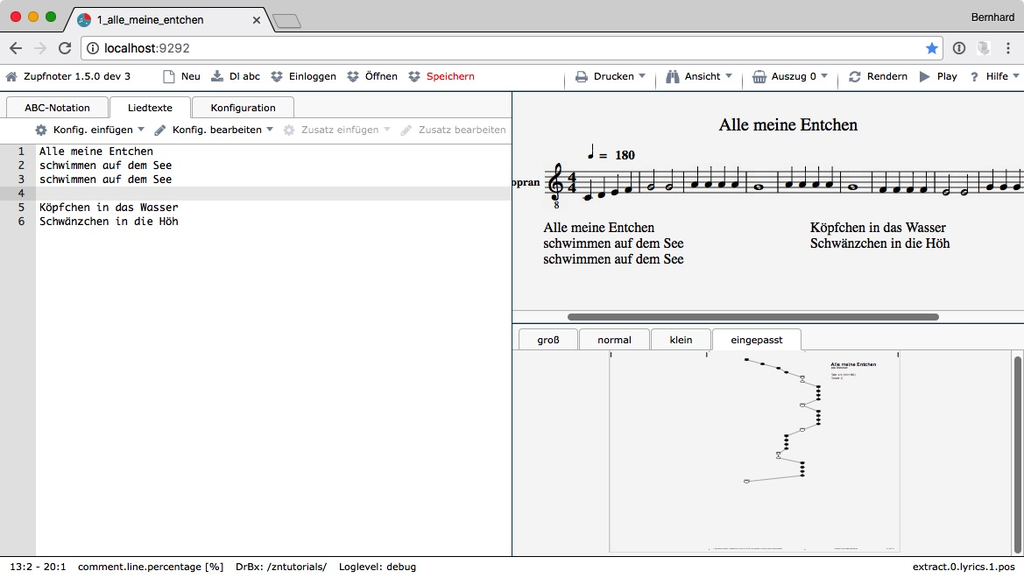

   Dieser Text erscheint sofort in dem Fenster rechts oben (der Notenvorschau), nicht jedoch in den Unterlegnoten. Dort erscheint der Liedtext erst, wenn die Einstellungen zur Gestaltung und Positionierung von Liedtexten eingefügt worden sind.

   > **Hinseis:** Leerzeichen in den Liedtexten werden komprimiert, d.h. zu einem Leerzeichen zusammengefasst. Leerzeichen am Anfang einer Zeile (führende Leerzeichen) werden ignoriert. Du kannst aber die Ausgabe eines Leerzeichens erzwingen, wenn du die Tilde (~) anstelle eines Leerzeichens verwendest.

   > ```
   >    W: alle meine Entchen
   >    W: schwimmen auf dem See
   >    W: schwimmen auf dem See
   >    W:
   >    W: Köpfchen in ds Wasser
   >    W: Schwänzchen in die Höh
   > ```

3. klicke auf die Schaltfläche “Konfig. bearbeiten”. Dadurch öffnet sich das Menü zum Einfügen von “Konfiguration” in das Musikstück.
4. klicke auf den Eintrag “Liedtexte”, um die Maske für Einstellungen für Liedtexte aufzurufen.
5. Klicke auf die Schaltfläche “Neuer Eintrag” um einen neuen Liedtextblock hinzuzufügen[^2]
6. Trage im Feld “Strophen” ein: “`1, 2`”, und bestätige die Eingabe durch Drücken der “Tab” - Taste.

   Das bedeutet, dass in dem neuen Liedtextblock die Strophen 1 und 2 ausgegeben werden.

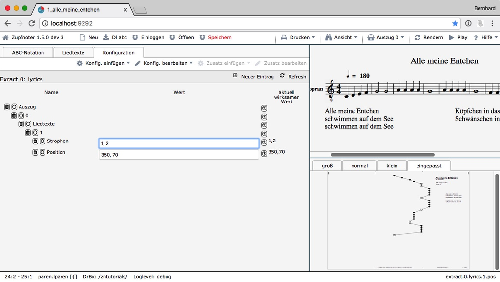

   Dadurch wird im linken Fenster folgendes eingefügt (zunächst musst du hier nichts tun. Wenn du einst ein Profi im Zupfnoter sein wirst, wirst du diese Zeilen schätzen lernen):

   ```
     "extract"  : {
       "0" : {"lyrics": {"1": {"verses": [1, 2], "pos": [350, 70]}}}
     },
   ```

7. klicke auf die Schaltfläche “Rendern”, um die Unterlegnoten zu aktualisieren.

   Nun erscheinen die Liedtexte:

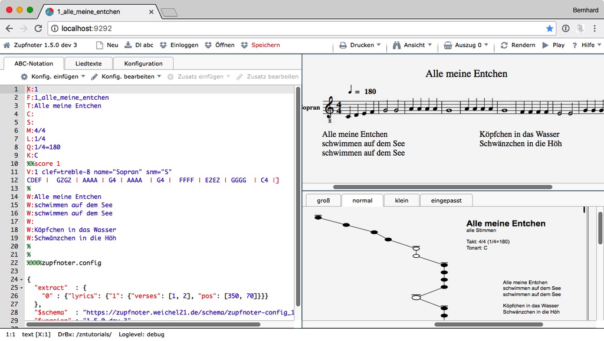

8. Verschiebe mit der Maus die Liedtexte in der Vorschau der Unterlegnoten (Fenster rechts unten) an die Position, die dir gefällt.

   > **Hinweis:** Der Liedtext ist nun rot, um bei nahe an einander liegenden Texten anzuzeigen, welcher Text verschoben wurde. Durch klicken auf die Schaltfläche “Rendern” wird er wieder schwarz.

## 3.5 Dein Musikstück drucken

Wenn das Musikstück fertig gestaltet ist, willst du es natürlich auch drucken:

1. klicke auf die Schaltfläche “Drucken”
2. klicke auf “A4” (oder auf “A3”, wenn du einen Din-A3 Drucker hast)

   Es erscheint eine Druckvorschau des Unterlegnotenblattes.
3. klicke auf das Druckersymbol oben rechts.

   Es öffnet sich der Druckdialog deines Browsers.

   > **Hinweis**: bitte konfiguriere die Druckereinstellung so, dass der Ausdruck **nicht vergößert oder verkleinert** wird (100%, 1:1, evtl. ‘randlos’ …).

[figure not shown]

   Schneide alle ausgedruckten Blätter an den linken Schnittmarken (die kleinen “x” oben und unten am Blatt) mittig im “x” durch und klebe die Blätter so zusammen, dass die Schnittmarken wieder genau ein “x” ergeben.

Wenn du dein Musikstück als herkömmliche Noten ausdrucken willst:

1. gehe zurück zum Zupfnoter und klicke erneut auf die Schaltfläche “Drucken”
2. klicke auf Menüeintrag “Noten”

   Es erscheint ein neuer Reiter in deinem Browser mit einer Vorschau der herkömmlichen Noten.
3. Wähle in deinem Browser zum Drucken die Druckfunktion aus.

## 3.6 Dein Musikstück speichern

Du hast vielleicht schon bemerkt, dass Zupfnoter bei einem Neustart immer das **zuletzt bearbeitete** Musikstück wieder geladen hat.

Da du aber nicht nur ein Musikstück schreiben willst, solltest du natürlich dein Musikstück auf deinem Rechner so abspeichern, dass du es später wieder laden und weiter bearbeiten kannst.

Zupfnoter bietet dazu zuwei Möglichkeiten:

- Speichern per Download: Das läuft vollkommen lokal, ist aber nicht sehr komfortabel
- Speichern in der Cloud (per Dropbox): Das nutzt die Cloud-Dienste, hat aber wesentliche Vorteile

### 3.6.1 Speichern per Download

Zum Speichern per Download führe folgende Schritte aus:

1. klicke auf die Schaltfläche “Dl abc”
2. dein Musikstück wird auf deinem Computer in deinem “Download-Ordner” abgelegt. Zupfnoter bildet den Dateinamen aus der Information in Zeile 2:

   aus “`F: 1_Alle-meine-Entchen`” entsteht “`1_Alle-meine-Entchen.abc`”

Bei Bedarf kannst du die Unterlegnoten als PDF herunterladen (z.B. um diese weiter zu geben):

1. klicke auf die Schaltfläche “Drucken”
2. klicke auf “A4” (oder auf “A3”, wenn du einen Din-A3 Drucker hast)

   Es erscheint eine Druckvorschau des Unterlegnotenblattes.
3. klicke auf das Downloadsymbol oben rechts
4. Wähle den Speicherort

   Zupfnoter bildet auch hier den Dateinamen aus der Information in Zeile 2:

   aus “`F: 1_Alle-meine-Entchen`” entsteht “`1_Alle-meine-Entchen_alle-Stimmen.pdf`”

### 3.6.2 Speichern in der Dropbox

Wenn du regelmäßig mit Zupfnoter arbeiten willst, bietet es sich an, zum Speichern der Muskstücke die Dropbox zu benutzen. Eine Dropbox ist ein Speicher außerhalb deines Rechners (in der “Cloud”). Mit der Dropbox hast du viele Vorteile bei Zupfbnoter:

- Zupfnoter speichert abc, pdf und Noten eines Musikstücks mit nur einem Klick
- du hast alle deine Musikstücke zentral abgelegt und kannst sie mit einem Klick wieder in den Zupfnoter laden

  > **Hinweis**: Beim Laden von Muskstücken in Zupfnoter, wird der Anfang des Dateinamens bis zum ersten “_” herangezogen. Daher muss pro Dropbox-Ordner diese Nummer eindeutig sein.
- Dropbox speichert frühere Versionen, so dass du bei Problemen darauf zurück greifen kannst und den Verlauf deiner Änderungen nachvollziehen kannst.
- Über die Dropbox kannst du deine Dateien mit anderen teilen, um gemeinsam an einem Musikstück zu arbeiten
- Selbst, wenn du nicht online bist, hast du jeweils eine Kopie aller deiner Musikstücke (auch der PDFs) auf deiner lokalen Platte [^3].

Zur Einrichtung einer Dropbox gehst du auf https://www.dropbox.com/de. Wenn du dich bei Dropbox angemeldet hast, findest du dort ein deutschsprachiges Benutzerhandbuch.

> **Hinweis**: Dropbox speichert seine Daten nicht in Deutschland [^4].

Wenn du ein Konto bei Dropbox hast, musst du Zupfnoter **einmalig pro verwendetem Browser** mit diesem Dropbox-Konto verbinden:

- klicke auf Schaltfläche “Einloggen” bzw. wähle das Menü “Dropbox > Einloggen”
- es erscheint der Zupfnoter - Dialog “Einloggen” - gib dort bitte ein Verezeichnis aus deiner Dropbox ein, in welcher du dein Musikstück speichern möchtest

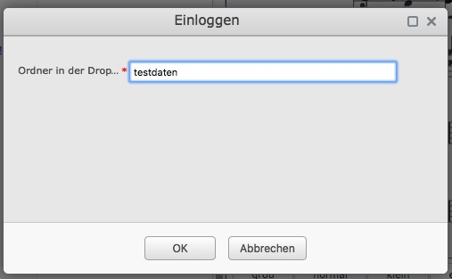

- klicke dann auf “OK”
- Um das Anmeldefenster der Dropbox zu erreichen, muss Zupfnoter kurzeitig verlassen werden. Diesen Vorgang musst du bestätigen:

[figure not shown]

- es erscheint das Anmeldefenster der **Dropbox** falls du nicht schno bei Dropobox eingeloggt bist
- gib dort Email-Adresse und Kennwort ein um dich bei Dropbox auszuweisen

[figure not shown]

- Dropbox fragt nun nach deiner Zustimmung, dass Zupfnoter auf Dateien in deiner Dropbox zugreifen kann. Bitte bestätige das.

[figure not shown]

- Dropbox kehrt nun zu Zupfnoter zurück. Zupfnoter ist nun mit der Dropbox verbunden.
- Drücke nun im Zupfnoter auf “Speichern”, (bzw. wähle das Menü “Dropbox > Speichern” )um dein Musikstück und die Auszüge als PDF-Dateien in deiner Dropbox zu speichern.

  > **HInweis**: Zupfnoter speichert in dem Verzeichnis, welches beim Einloggen angegeben wurde. Fall das Verzeichnis nicht existiert, wird es angelegt. Bitte achte auf also die richtige Schreibweise

Zupfnoter hat nun im Prinzip Zugriff alle Dateien in deiner Dropbox. Zupfnoter verwendet jedoch nur folgende Dateitypen in deiner Dropbox:

- schreibt “abc”, “pdf”, “html”"
- liest “abc”

> **Hinweis zur Sicherheit** z.B. bei Verwendung fremder Computer (z.B. im Internet-Cafe):
> - Solange du mit deinem Browser bei Dropbox angemeldet bist, hat der Browser Zugriff auf alle deine Dateien[^5]. Daher musst du dich in **unbedingt in *allen* Browser-Fenstern von der Dropbox** abmelden, wenn du an einem fremden Computer arbeitest.

>   Es ist auf jeden Fall sinnvoll, an fremden Computern im “inkognito - Modus” des Browsers zu arbeiten.
> - Dropbox-Anwendungen speichern ein geheime Zeichenkette (auch “Accesstoken” genannt) auf deineme lokalen Rechner. Wenn du vermutest, das dieses Token kompromittiert wurde, kannst du auf der Website von Dropbox die Verbindung zu Zupfnoter löschen. Dadurch wird bei der nächsten Anmeldung ein neues Token erzeugt.

>   Gehe dazu auf https://www.dropbox.com/account#security. Dort kannst du sehen, welche Anwendungen bzw. welche Sitzungen mit deiner Dropbox verbunden sind. Diese kannst du hier auch löschen.
> - Dropbox sendet dir eine E-Mail, wenn immer du eine Anwendung mit deiner Dropbox verbindest.
> - Im Menu “Dropbox > Ausloggen” kannst du Zupfnoter von deiner Dropbox trennen. Das Accesstoken wird dabei auch bei Dropbox gelöscht. Du musst dich ggf. neu anmelden um wieder mit Dropbox arbeiten zu können.

## 3.7 Musikstück aus Dropbox laden

Um das Musikstück wieder zu laden, klicke auf “Öffnen” bzw. wähle das Menü “Dropbox > Öfnnen. Es erscheint ein Datei-Auswahl-Dialog von Dropbox. Dort ist oben ein Suchfeld. Dort kannst du einen Teil des Dateinamens eingeben, um die gewünschte Datei zu suchen.

> **Hinweis**: Wenn du im Suchfeld die Zeichenkette “abc” voanstellst, dann werden nur noch ABC-Datien angezeigt. Wenn du zum Beispiel im Suchfeld eingibst: `abc ent`, dann werden alle Dateien gesucht, in deren Namen die Worte ‘abc’ vorkomment und mit ‘ent’ beginnen

[figure not shown]

> **Hinweis**: Zupfnoter loggt sich in das Verzeichnis der zuletzt geöffneten Datei ein. Du kannst am unteren Rand vo Zupfnoter sehen, in welches Dropbox-Verzeichnis Zupfnoter speichert.

## 3.8 Musikstück importieren

Falls du schon ein anderes Musikprogramm verwendest (z.B. Musescore https://www.musescore.com) kannst du deine Musikstücke in den Zupfnoter importieren, wenn dein anderes Musikprogramm das Dateiformat “MusicXml” (https://www.musicxml.com/de/) exportieren kann.

Es gibt auch Webseiten, die frei zugängliche Musikstücke in den Dateiformaten “MusicXML (.xml)” oder “ABC-Notation (.abc)” zum Download anbieten[^6].

> **Hinweis** MuseScore ist sowohl der Name eines Musikprogrammes als auch er Name einer Website, welche Musikstücke zum Downlaod anbietet. Du kannst hier auch die “komprimierten XML-Dateien” mit der Endung “.mxl” verwenden.

Um ABC oder MusicXML zu importieren, kannst du einfach die Datei aus deinem Rechner (Windows: Datei-Explorer oder Mac: Finder) in den Zupfnoter ziehen. Zupfnoter übersetzt dann das XML-Format in Abc Notation.

Bei der Auswahl eines Musikstückes im xml-Format sollte man 30 Takte nicht überschreiten. Am besten eignen sich Klaviernoten für den Import. Ausserdem sollte man auf die Bandbreite der Noten achten, die Tisch-Harfen mit 25 Saiten haben einen Tonumfang von zwei Oktaven (G bis g).

In der Regel ist etwas Nacharbeit erforderlich, um das importierte Musikstück für die Tischharfe anzupassen.

> **Hinweis**: bitte achte darauf, dass du die Zeile “F:” ggf. von Hand hinzufügst, damit Zupfnoter den Dateinamen kennt unter welchem er das Musikstück speichern soll.

# 4 Zupfnoter - Übersicht für Einsteiger und Experten

Zum Verständnis von Zupfnoter sind folgende Themen wichtig:

## 4.1 Zupfnoter Prinzipien

Zupfnoter arbeitet nach dem Prinzip der Umwandlung von ABC-Notation in Unterlegnoten. Im Gegensatz zu so genanten “what you see is what you get” - Systemen werden also die Unterlegnoten nicht direkt bearbeiter, sondern entstehen automatisch durch Umwandlung aus einem Modell des Musikstückes.

Dieses Modell ist allgemeiner und präziser als die Unterlegnoten und basiert auf der ABC-Notation als ein de-facto Standard. Wie du siehst kann aus diesem Modell (der ABC-Notation) ja auch ein herkömmliches Notenblatt erstellt werden. In diesem Sinne sind die Unterlegnoten lediglich eine von mehreren grafischen Darstellungen des Musikstückes.

Andererseits gibt es im Gengensatz zur den herkömmlichen Noten in den Unterlegnoten spezifische Sachverhalte, deren Darstellung in der ABC-Notation nicht standardisiert sind. Daher verwendet Zupfnoter zusätzlich zwei spezifische Darstellungen (Konventionen) innerhalb der ABC-Notation:

- **Zusätze** zu Noten und Taktstrichen: Hier werden die “Annotations” der ABC-Notation mit spezifischen Formaten verwendet. Diese Zusätze stehen vor der Note bzw. dem Taktstrich auf den sie sich beziehen.

  Für die Erstellung und Bearbeitung dieser “Zusätze” gibt es eine grafische Benutzerführung durch Bildschirmmasken (Siehe Kapitel Zusätze).
- **Konfiguration** der Unterlegnoten: Zupfnoter gewinnt seine Leistungsfähigkit und Flexibilität durch vielfältige Einstellmöglichkeiten - genannt Konfigurationsparameter. Diese Konfigurationsparameter wirken auf die Erstellung der Unterlegnotenblätter und steuern z.B:
  - Stimmen, die ausgegeben werden; Stimmen durch Synchronisiationslinien verbunden werden usw.
  - Größe von Notenelementen, Liniendicken
  - Beschriftungen

  Die Konfigurationsparameter sind thematisch hierarchisiert (z.B. `extract.0.layout` `extract.0.printer`). Eine Referenz und Erläuterung zu den Konfigurationsparametern findst du in Konfiguration.

  Für die Bearbeitung der Konfigurationsmparameter gibt es Bildschirmmasken (siehe Kapitel Konfigurationsmasken)

  Zupfnoter speichert die Konfigurationsparameter im so genannten JSON-Format in einem Abschnitt nach der ABC-Notation, der durch

  `%%%%zupfnoter.config`

  abgesetzt ist.

[figure not shown]

Zupfnoter Elemente

## 4.2 Elemente der von Zupfnoter erstellten Unterlegnoten

Das Bild auf der vorigen Seite zeigt die Elemente und Merkmale aus denen Zupfnoter ein Unterlegnotenblatt aufbaut. In den nachfolgenden Unterkapiteln werden die einzelnen Elemente und Merkmale dieser Darstellung erläutert. Als Referenz dient die Nummer in dieser Abbildung.

Bei manchen Elementen ist auch eine Konfiguration notwendig. Die nachfolgende Beschreibung enthält auch einen verweise auf den (internen) Namen des entsprechenden Kongigurationsparameters.

> **Hinweis**: In dieser Darstellung sind die englischen Begriffe aufgelistet. Für diese Auflistung wurde die Funktion “Liedtexte” verwendet.

### 4.2.1 Darstellung der Noten

In der ABC-Notation wird in den Kopfzeilen ein Standardnotenwert angegeben, z.B. `L:1/4`. Dies bedeutet, daß standardmäßig in Viertelnoten erfasst wird. Ausgehend von diesem Wert ergibt sich der Notenwert duch Multiplikation mit der angegebenen Länge. Diese Längenangaben wird an den Notennamen angehängt.

TODO: verweise auf ABC-Kapitel

Im Folgenden wird von **Vierteln als Standardnotenwert** und dem Notennamen **`C`** ausgegangen.

- **(1) full note - ganze Note** entspricht in ABC-Notation: `C4`
- **(2) half note - halbe Note** entspricht in ABC-Notation: `C2`
- **(3) quarter note - viertel Note** entspricht in ABC-Notation: `C` oder `C1`
- **(4) eighth note - achtel Note** entspricht in ABC-Notation: `C1/2` oder `C/`
- **(5) sixteenth note - sechzehntel Note** entspricht in ABC-Notation: `C1/4` oder `C//`
- **(6) punctuated half note - punktierte halbe Note** entspricht in ABC-Notation: `C3`
- **(7) punctuated quarter note - punktierte viertel Note** entspricht in ABC-Notation: `C3/2` (also drei halbe Viertel :-)

### 4.2.2 Darstellung von Pausen

Im Folgenden wird von **Vierteln als Standardnotenwert** ausgegangen.

- **(11) full rest - ganze Pause** entspricht in ABC-Notation: `z4`
- **(12) half rest - halbe Pause** entspricht in ABC-Notation: `z2`
- **(13) quarter rest- viertel Pause** entspricht in ABC-Notation: `z` oder `z1`
- **(14) eighth rest - achtel Pause** entspricht in ABC-Notation: `z1/2` oder `z/`
- **(15) sixteenth rest - sechzehntel Pause** entspricht in ABC-Notation: `z1/4` oder `z//`
- **(16) punctuated half rest - punktierte halbe Pause** entspricht in ABC-Notation: `z3`
- **(17) punctuated quarter rest - punktierte viertel Pause** entspricht in ABC-Notation: `z3/2` (also drei halbe Viertel :-)

### 4.2.3 Darstellung notenbezogener Elemente

Um auf den Unterlegnoten einzelnen Noten graphische Elemente oder Texte hinzuzufügen gibt es bei Zupfnoter Elemente, die fest mit Noten verbunden sind. Da sie im Kontext von Noten positioniert werden, nennt man sie “notenbezogene Elemente”:

- **(20) measure bar - Taktstrich**: Der Taktstrich entsteht aus der Takteingabe in der ABC-Notation (z.B. `|` `|]`). Zur Eingabe dieser Sonderzeichen siehe Kapitel Tastenkombinationen für Sonderzeichen
- **(21) unison - Mehrklang**:  
  Ein Mehrklang entsteht, wenn in der ABC-Notation mehrere Noten in einer eckigen Klammer eingegeben werden (z.B. `[FA]`). Damit kann man innerhalb **einer** Stimme mehrere Noten spielen.

  Die Noten eines Mehrklanges werden automatisch mit einer Synchronisationslinie verbunden.

  > **Hinweis**: Dieser Mehrklang sieht in den Unterlegnoten nahezu gleich wie der Zusammenklang von Tönen aus mehreren Stimmen aus. Man kann sie jedoch anhand der Flußlinie unterscheiden und den jeweiligen Stimmen zuordnen.

  > **Hinweis**: Die Angabe von Akkordsymbolen in der ABC-Notation wird für die Unterlegnoten ignoriert.

  Meist ist es so, dass bei Mehrklängen die höchste Note die Melodieführung übernimmt. Daher wird bei einem Mehrklang die Flußlinie and die letzte Note geführt.

  > **Hinweis**: Wenn man das anders haben möchte, muss man die Reihenfolge der Noten in der ABC-Notation verändern oder doe “Führungsnote” als letzte Note wiederholen. Beispiel:
  > - `[CEG]` - Die Flußlinie geht an `G`
  > - `[GEC]` - Die Flußlinie geht an `C`
  > - `[CEGC]` - Die Flußlinie geht an `C`
- **(22) triplet - Triole**: Bei einer Triole werden drei Noten auf zwei Schläge verteilt. Bei einer Triole werden Anfang und Ende einer Reihe von Noten mit einem Bogen verbunden. Die Länge der Triole wird an den Bogen geschrieben. Eine Verallgemeinerung der Triole ist das Tuplet. Dieses verteilt n Noten auf m Schläge. Zupfnoter kann beliebige Tuplets, auch wenn bei Tischharfen meistens nur Triolen verwendet werden.

  Ein Tuplet entsteht, wenn in der ABC-Notation den Noten der Tuplets eine Klammer mit der Länge des Tupletes vorangestellt wird, z.B: “`(3CCC`”.
- **(23) tie - Haltebogen**: Ein Haltebogen verbindet zwei Noten gleicher Höhe miteinander. Dabei wird nur die erste Noten angeschlagen. Ein Haltebogen entsteht, wenn in der ABC-Notation die Noten durch einen Bindestrich verbunden sind, z.B. “`A -|A`”.

  > **Hinweis**: Der Haltebogen ist zu unterscheiden vom Bindebogen, welcher in der Notenansicht gleich aussieht, in den Unterlegnoten jedoch nicht ausgegeben wird, da man ihn auf der Tischharfe nicht spielen kann. Der Bindebogen wird in der ABC-Notation durch Einklammern der Noten erstellt, z.B. “`(A|A)`”.
- **(24) repeat signs - Wiederholungszeichen**: Eine Wiederholung entsteht durch Beifügen eines Doppelpunktes an die Taktstriche in der ABC-Notation, z.B. “`|: C4 :|`”.

  > **Hinweis** Wiederholungszeichen sind eine Alternative zu Sprunglinien. Ihre Ausgabe hängt von der aktuellen Konfiguration ab (siehe Kapitel `repeatsigns`).
- (25), (26) siehe nächster Abschnitt
- **(27) part note - Bezeichnung von Abschnitten im Musikstück**: Man kann ein Musikstück in Abschnitte aufteilen. Die Abschnitte können bezeichnet werden, z.B. als “Teil 1”. Der Abschnitt unterbricht auch die Flusslinien. Dieses Element wird häufig genutzt, um Abfolgen von Abschnitten beim Spielen festzulegen.

  Ein Abschnitt entsteht, wenn in der ABC-Notation der ersten Note des neuen Abschnittes z.B. die Zeichenfolge “`[P:Teil 1]`” vorangestellt wird. Hier ist “Teil 1” die Bezeichnung des Abschnitts.

  > **Hinweis:** Die Aufteilung in Abschnitte gilt für das gesamte Musikstück. daher muss die Bezeichung von Abschnitten in der **ersten Stimme** erfolgen. Sie wirkt dann auf alle Stimmen. Abschnittsbezeichungen in den folgenden Stimmen werden ignoriert.
- **(28) countnotes - Zählhilfen**: Zupfnoter kann die Noten automatisch mit Zählhilfen beschriften. Die Zählweise ergibt sich aus der Taktangabe. Beispiel siehe Abbildung [Zupfnoter Elemente]. Diese Ausgabe (für welche Stimmen, Position) ist konfigurationsabhängig (`extract.0.countnotes`).

  > **Hinweis** die Zählhilfen sind so gesataltet, dass man während des Spields die Zeitachse durchzählt. Bei Noten mit mehreren Schlägen beginnt die Zählhilfe immer mit der Nummer des ersten Schlages (z.B. 2-3 ist eine Note, die bei Schlag 2 beginnt und zwei Schläge lang gespielt wird, d.h. während diese Note klingt, zählt man 2 - 3)
- **(29) barnumbers - Taktnummer**: Zupfnoter kann die Takte automatisch durchnummerieren. Damit kann bei gemeinsamem Spiel auch mitten im Musikstück wieder eingesetz werden. Diese Ausgabe ist konfigurationsabhängig (`extract.0.barnumbers`.
- **(30) decoration - Dekoration**: Zupfnoter kann einzelne Dekorationen (Stand Version 1.5 nur die Fermate) darstellen. Für diese Dekorationen werden die Eingaben der ABC-Notation verwendet (z.B. für die Fermate : “`!fermata!`” oder “`H`”).

### 4.2.4 Darstellung von Verbindungslinien

Um auf den Unterlegenoten die Zusammenhänge zwischen Noten darzustellen, gibt es folgende Elemente:

- **(25) jumpline for repeat - Sprungline für Wiederholungen**: Eine Wiederholung entsteht durch Beifügen eines Doppelpunktes an die Taktstriche in der ABC-Notation z.B. “`|: C4 :|`”.

  > **Hinweis** Wiederholungszeichen sind eine Alternative zu Sprunglinien. Ihre Ausgabe hängt von der aktuellen Konfiguration ab (siehe Kapitel `extract.0.repeatsigns`).
- **(26) synchline for unison - Synchronisationslinie für Mehrklang**: siehe (21) in Kapitel Darstellung notenbezogener Elemente
- **(31) flowline - Flusslinie**: Die Flußlinie[^7] verbindet die Noten **einer** Stimme und markiert so die Führung innerhalb dieser **einen** Stimme. Standardmäßig stellt Zupfnoter die Flußline in der ersten und dritten Stimme dar.

  Die Ausgabe von Flusslinien für die einzelnen Stimmen hängt von der aktuellen Konfiguration (siehe Kapitel extract.0.flowlines) ab.
- **(32) synchline - Synchronisationslinie**: Die Synchronisationslinien verbinden Noten aus zwei **verschiedenen Stimmen**, die zum gleichen Zeitöpunt gespielt werden. Standardmäßig stellt Zupfnoter die Synchronisationslinie zwischen den Stimmen *eins und zwei* sowie *drei und vier* dar.

  Die Ausgabe von Synchronisationslinien für die einzelnen Stimmen hängt von der aktuellen Konfiguration (siehe Kapitel extract.0.synchlines) ab.
- **(33) subflowline - Unterflusslinie**: Die Unterflusslinie verbindet innerhalb einer Stimme ohne Flußlinie diejenigen Noten, die nicht über eine Synchronisationslinie (32) mit einer anderen Stimme verbunden sind.

  Die Ausgabe von Unterlusslinien für die einzelnen Stimmen hängt von der aktuellen Konfiguration (siehe Kapitel extract.0.subflowlines) ab.
- (34), (35), (36) siehe Kapitel Elemente für das gesamte Musikstück
- **(50) variant ending - variante Enden - Volten**: Wo mehrfach gespielte Abschnitte unterschiedlich enden, bezeichnet man das als variante Enden. In der ABC-Notation schreibt man hierfür Ziffern (z.B. 1 und 2) unmittelbar hinter den Taktstrich bei dem die Variation beginnt.

  Zupfnoter stellt diese varianten Enden als eine Menge von Sprunglinien dar:
  - **(51) Eingangslinie** (im Beispiel links): Es gibt pro Variation eine Linie, welche zum Anfang der Variation führt
  - **(52) Ausgangslinie** (im Beispiel rechts): Es gibt pro Variation eine Ausgangslinie, welche zur nächsten Note nach der letzten Variation führt.

    > **Hinweis**: Wenn die Varianten am Ende einer Wiederholung stehen, entfällt die Ausgangslinie. Stattdessen wird eine normale **(25) Sprunglinie für Wiederholung** verwendet. Die Positionsangabe der Ausganslinie wird in diesem Fall ignoriert und die Positionsangabe der Sprunglinie am Ender der Wiederholung verwendet.
  - **(53) Folgelinie** ist die Ausgangslinie der letzten Variation. Diese kann separat positioniert werden, um das gwünschte Notenbild zu erreichen.

  Die Positionen deieser Linien werden als Zusatz vor den Taktstrich der ersten Variation geschrieben (Schaltfläche “Zusatz einfügen” bzw. “Zusatz bearbeiten”)

### 4.2.5 Elemente für das gesamte Musikstück bzw. Unterlegnotenblatt

Um auf den Unterlegnoten Texte und Beschriftungen allgemeiner Art darstellen zu können, gibt es folgende Elemente:

- **(34) legend - Legende**: Die Legende enthält die grundsätzlichen Informationen über das Musikstück. Die Inhalte der Legende werden aus den Kopfzeilen der ABC-Notation übernommen:
  - Titel des Musikstücks (ABC-Notation Zeile “`T:`”)
  - Titel des Auszugs siehe (35)
  - Autoren des Musikstücks bzw. Liedes (ABC-Notation Zeile “`C:`”)
  - Takt des Musikstücks (ABC-Notation Zeile “`M:`”)
  - Empfohlene Geschwindigkeit (ABC-Notation Zeile “`Q:`”)
  - Tonart des Musikstücks (ABC-Notation Zeile “`K:`”)
  - Tonart der Druckausgaben falls das Musikstück transponiert wurde

  Die Legende kann mit der Maus im rechten unteren Fenster auf den Unterlegnoten optimal positioniert werden.
- **(35) extract title in legend - Titel des Auszugs**: Dies bezeichnet den Titel des Auszuges (siehe Konfiguration extract.x.title bzw. Kapitel Auszüge).
- **(36) lyrics - Liedtexte**: Zupfnoter stellt auch Liedtexte dar. Diese Liedtexte (siehe auch Kapitel ) werden aus aufeinander folgenden Kopfzeilen der ABC-Notation entnommen (`W:`) und zu Strophen zusammengefügt. Einzelne Strophen trennt man mit einer “Leerzeile” (“`W:`”)

  ```
  W: Strophe 1 Zeile 1
  W: Strophe 1 Zeile 2
  W:
  W: Strophe 2 Zeile 1
  W: Strophe 2 Zeile 2
  ```

  > **Hinweis**: Die Ausgabe der Strophen muß über die Konfiguration eingestellt werden (siehe Kapitel extract.x.lyrics).

  > **Hinweis**: In der ABC-Notation kann man Liedtexte mit sowhohl mit Kopfzeile `W:`(Großbuchstaben) als auch mit Kopfzeile `w:` (Kleionbuchstaben) eingeben. Die Variante mot Kleinbuchstaben wird verwendet, um die Lietexte direkt in die Notensyteme zu schreiben. Zupfnoter ignoriert diese Liedtexte in den Notenlinien

  > **Hinweis**: Auch wenn die ABC-Notation es erlaubt, die Kopfzeilen `W:` im ganezn ABC-Text zu verteilen ist es wichtig, die Liedtexte dennoch in einem Block zusammenzufassen. Sonst meldet Zupfnoter, dass es mehrere Liedtexte gibt. Der Editor fasst sie alle zusammen, löscht aber die anderen Blöcke nicht. Das muss manuell korrigiert werden.

  > **Hinweis**: Zupfnoter ignoriert Leerzeichen am Anfang von Liedtexten. Macnhmal möchte man aber den Liedtext in bestimmten Zeilen etwas einrücken um den Text um eine Note im Unterlegnotenblatt herumfließen zu lassen. Wenn aleo eine Textzeile mit einer Reihe Tilde (`~`) - Zeichen beginnt werden diese in den Unterlegnoten als Leerraum ausgegeben und so der Textbeginn nach rechts verschoben.

  ```
          W: Strophe 1 Zeile 1
          W: ~Strophe 1 Zeile 2
          W: ~~Strophe 1 Zeile 2
          W: ~~~Strophe 1 Zeile 2
  ```

### 4.2.6 Elemente zur Handhabung des Unterlegnotenblattes

Zupfnoter druckt Elemente auf das Unterlegnotenblatt, um das Zuschneiden und das Einelgen in das Instrument zu vereinfachen:

- **(37) stringnames - Saitennamen**: Zupfnoter kann die Namen der Saiten auf den Unterlegnoten ausgeben.

  > **Hinweis**: Über die [Einstellungen in der Konfiguration] kann die Ausgabe von Saitennamen eingestellt werden (siehe Kapitel extract.0.stringnames).
- **(38) marks - Saitenmarke** Die Saitenmarken sind eine Hilfe zum korrekten Einlegen der Unterlegnoten in die Tischharfe. Das Blatt muss so in die Tischharfe eingelegt werden, dass die Marken unter den G-Saiten liegen.

  > **Hinweis:** Über die [Einstellungen in der Konfiguration] kann die Ausgabe der Saitenmarken beeinflusst werden (siehe Kapitel extract.0.stringnames.marks).
- **(39) cutmarks - Schneidemarken**: Die Schneidemarken sind eine Zuschneidehilfe für den Fall, dass die Unterlegnoten auf DIN-A4 Seiten ausgegeben werden (Siehe Kapitel Musikstück drucken).

### 4.2.7 Elemente zur Organisation von Unterlegnoten

- **(70) input filename - Name der Eingabedatei**: Der Name der Eingabedatei hilft, den Ursprung eines ausgedruckten Blattes nachzuvollziehen. Er wird immer auf den Unterlegnoten ausgegeben und kann nicht unterdrückt werden.
- **(71) creation note - Erstellungsnotiz**: Die Erstellungsnotiz gibt weitere Informationen zum technischen Stand der Erstellung. Diese wird immer auf den Unterlegnoten ausgegeben und kann nicht unterdrückt werden. Die Erstellungsnotiz hilft beim Nachvollziehen von Veränderungen und besteht aus
  - Zeitpunkt der Erstellung der PDF-Datei (CEST steht für “*C*entral *E*uropean *S*ummer *T*ime”)
  - Software-Version von Zupfnoter
  - Server von welchem der Zupfnoter geladen wurde
- **(72) reference to zupfnoter website - Referenz auf Zupfnoter Website**: Dies ist die Referenz auf Zupf-  
  noter als Werkzeug zur Erstellung des Unterlegnotenblattes, also Werbung in eigener Sache. Diese wird immer auf den Unterlegnoten ausgegeben und kann nicht unterdrückt werden.
- **(73) fingerprint - Fingerabdruck**: Diese Nummer ist wie ein Fingerabdruck der ABC-Datei. Dies bedeutet, dass Unterlegnoten (z.b. verschiedene Auszüge) mit dem selben Fingerabdruck auch aus einer identischen Quelle stammen und somit zuverlässig zusammen passen.

  > **Hinweis:** Der Fingerabdruck wird aus dem ABC-Text errechnet und ist daher nicht im ABC-Text enthalten.

### 4.2.8 Vordefinierte Blattbeschriftungen

Zupfnoter bietet eine Reihe von Vorlagen für die Seitenbeschrifungen. Damit lässt sich ein einheitliches Vorgehen bei der Beschrifung der Unterlegnoten erreichen. Diese können in der Konfigurationsmaske “Seitenbeschriftung” eingegeben werden. Zupfnoter hat geeignete Vorgabewerte für die Position und Schriftart dieser Beschriftungen.

- **(74) T04 to order - zu beziehen bei**: Hier kann man angeben, über welche Adresse das Unterlegnotenblatt bezogen werden kann (Konfiguration siehe Kapitel presets.notes.T04_to_order. Das ist natürlich nur sinnvoll, wenn es für die erstellen Unterlegnoten einen Vertriebsweg gibt.
- **(75) T02 Copryright music - Urheberrechte für das Stück**: Hier kann mam die Urheberrechte für das Musikstück angeben (Konfiguration siehe Kapitel presets.notes.T02_copyright_music. Es wird empfohlen, diese Rechte immer anzugeben und den Satz “Privatkopie” hinzuzufügen, wenn mit dem Rechteinhaber keine Vereinbarung geschlossen wurde.

  Z.B. ist dann `RBW-320` das Blatt 320 aus der Werkstatt von Ruth und Bernhard Weichel.
- **(79) T01 Number extract - Kürzel für den Auszug**: Hier kannst du ein Kürzel für den Auszug angebeen (Konfiguration siehe Kapitel presets.notes.T01_number_extract)

### 4.2.9 Zusammenfassung der Beschriftungen in Zupfnoter

Zupfnoter hat vielfältige Möglichkeiten, das Beschriftungen einzufügen. Auf den Unterlegnoten sind diese nicht leider nicht immer zu unterscheiden. Daher wird hier noch einmal eine Zusammenfassung gegeben:

- **Standardbeschriftungen** (siehe Kapitel Elemente für das gesamte Musikstück)

  Die Standardbeschriftung wird aus der Kopfzeilen der ABC-Notation entnommen, sie erscheint auch auf den herkömmlichen Noten.
- **Notenbeschriftung**

  Die Notenbeschriftung ist mit einer einzelnen Note verbunden und verschiebt sich ggf. wenn die Tonhöhe oder der Zeitbezug dieser Note verändert wird. Die Notenbeschriftung wird über einen “Zusatz” direkt in die ABC-Notation eingefügt (siehe Kapitel Darstellung notenbezogener Elemente).

  Für wiederkehrende Texte bzw. längere und mehrzeilige Texte in der Konfiguration eine Notenbeschriftungsvorlage (Kapitel annotations mit Positionsangabe anlegen und über einen Zusatz (Schaltfläche “Ref. Notenbeschriftung”) daraus eine Notenbeschrifung erstellen.

  > **Hinweis**: Zupfnoter kennt standardmäßig die Noptenbeschriftungsvorlagen `vl` `vt`, `vr`. Damoit kann man einfach ein “Abdämpfungszeichen” anbringen. [^9].

  Im Zusatz kann eine Position mit angegeben angegeben werden. Damit bleibt die Position der Notenbeschriftung erhalten, auch wenn der Zeitbezug der Note geändert wird.

  > **Hinweis** Wenn man die Notenbeschriftung mit der Maus verschiebt, wirkt nur noch diese Verschiebung ud die Angabe im Zusatz wird ignoriert. Diese Verschiebung wird in der Konfiguration gespeichert und ist an die die Startzeit der Note gebunden, solange keine Verschiebemarke in der ABC-Notation eingefügt ist ([extract.x.notebound.annotation.v_{voice}.{time}]).
- **Seitenbeschriftung**

  Die Seitenbeschriftungen werden ausschliesslich über die Konfiguration hinzugefügt (Kapitel extract.x.notes. Ihre Anordnung bezieht sich auf den Seitenrand. Der Schriftstil kann gewählt werden (siehe auch Kapitel Elemente für das gesamte Musikstück).
- **Liedtexte**

  Liedtexte werden in den `W:` - Zeilen in der ABC-Notation erfasst und über die Konfiguration (Kapitel extract.x.lyrics.x) auf dem Blatt positioniert.

  Für weitere Einzelheiten siehe auch Kapitel Elemente für das ganze Blatt.

## 4.3 Zupfnoter Bildschirmaufbau

Die Benutzungsoberfläche von Zupfnoter ist aus folgenden Elementen aufgebaut:

- Fenster (Eingabe, Notenvorschau, Unterlegnotenvorschau) (Kapitel Fensteraufbau) mit mit Reitern, Werkzueugleisten und Kontextmenüs
- Werkzeugleiste (Kapitel Menüs im Hauptfenster)
- Statusleiste (Kapitel Statusleiste

[figure not shown]

### 4.3.1 Fensteraufbau

Zupfnoter kennt drei Fenster[^10]:

- Das **linken Fenster** zeigt die Eingabemöglichkeiten über drei Reiter (Kapitel Eingabe):
  - `ABC`- Der Texteditor für die ABC-Notation
  - `Liedtextexte` für die Erfassung der Liedtexte
  - `Konfiguration` für die formulargeführte Bearbeitung der Zupfnoter-Konfiguration.
- Im **rechten oberen Fenster** (Kapitel Eingabe) wird in der herkömmlichen Notenschrift das Musikstück gezeigt, und kann somit musikallisch überprüft wreden.

  Die Darstellung in herkömmlicher Notenschrift kann mehrstimmig erfolgen (gesteuert über die `%%score` - Anweisung in der ABC-Notation). Wenn das Musikstück Texte enthält (also ein Lied ist), werden diese Texte auch in der Notenvorschau angezeigt.
- Im **rechten unteren Fenster** werden die Unterlegnoten angezeigt. Diese entsprechen inhaltlich der herkömmlichen Notenschrift im rechten oberen Fenster (Kapitel Eingabe).

  Über die Reiter können verschiedene Zoom-Stufen eingestellt werden.

  > **Hinweis**: Da die Berechnung der Unterlegnoten einige Sekunden dauert, wird dieses Fenster nur durch `Rendern` aktualisiert.

Die Anordnung dieser Fenster ist in Zupfnoter fest vorgegeben. Man kann aber während der Arbeit folgende Einstellungen vornehmen, um den aktuellen Arbeitsschrit besser zu unterstützen:

- Fenstergröße verstellen: Die Trennlinien zwischen den Fenstern können mit der MAus verschoben werden, um Platz für die aktuell wichtigen Elemente zu schaffen
- Über das Menü “Ansicht” kann man einzelne Fenster ausblenden so dass die anderen Fenster größer werden (Siehe Kapitel Werkzeugleiste für Schaltflächen und Menüs

Innerhalb dieser Fenster gibt es weitere **Bedienelemente**:

- **Reiter** zum Auswählen verschiedener Ansichten
- **Werkzeugleiste** Leiste für Schaltflächen und Menüs
- **Kontextmenü**: zur speziellen Bearbeitung von Elementen (erreichbar mit rechte Maustaste)

Über die drei festen Fenster hinaus gibt es **Dialoge**. Das sind Fenster die aufscheinen, um bestimmte Informationen einzugeben bzw. zu ändern (z.B. Dialog im Kapitel Dein erstes Musikstück eingeben).

> **Hinweis**: Der Begriff “Fenster” wird sowohl für die Fenster des Betriebssytems als auch die Fenster innerhalb Zupfnoter verwendet.

### 4.3.2 Werkzeugleiste für Schaltflächen und Menüs

Die Zupfnoter - Werkzeugleiste ist immer sichtbar (also auch in allen Ansichten) und ersteckt sich über aller Fenster. In ihr befinden sich Schaltflächen und Menüs die man während der Erstellung von Unterlegnoten benötigt. Nach einem Klick auf die Schaltflächen führt der Zupfnoter bestimmte Aktivitäten aus.

Einige Funktionen sind auch über Tastenkombinationen (Shortcuts) erreichbar (siehe Kapitel Shortcuts)

> **Hinweis**: Für die Vesrion 1.5 wird die Bedienungsoberfläche von Zupfnoter verbessert. Daher sind die Informationen in diesem Kapitel vorläufig.
- Schaltfläche **Zupfnoter**: TODO: – Detailinfo als Popup darstellen
- Schaltfläche **Neu** (erstellen): Es wird ein leerer Bildschirm ohne Inhalte erstellt und man kann ein neues Musikstück erstellen (siehe Kapitel Dein erstes Musikstück eingeben).
- Schaltfläche **Einloggen**: TODO: - https://github.com/bwl21/zupfnoter/issues/75

  Über diese Schaltfläche kannst du das Verzeichnis in der Dropbox angeben, in die Zupfnoter dein Musikstück speichern soll.
- Schaltfläche **DL abc** (Download ABC): Hiermit kann man Zwischenstände oder fertige Musikstücke als ABC-Datei auf seinen Rechner herunterladen. Abgelegte Dateien können mit der Maus wieder in den Zupfnoter in den linken Abschnitt gezogen werden und der Inhalt steht zur Bearbeitung im Zupfnoter wieder zur Verfügung.
- Schaltfläche **Öffnen**: Es öffnet sich ein Dateiauswahlfenster deiner Dropbox. Dort kannst du eine Datei auswählen und zur Bearbeitung im Zupfnoter öffnen.

  TODO: anpassen auf kommenden Dialog

  > **Hinweis**: in der Statuszeile wird der Verbindungszustand zur Dropbox und auch das aktuelle Verzeichnis in der Dropbox angezeigt. “Not connected” bedeutet, das Zupfnoter nicht mit deiner Dropbox verbundn ist.
- Schaltfläche **Speichern** (sichern): Das fertig gestellte Musikstück wird in deiner Dropbox gespeichert. Es wird eine ABC-Datei, jeweils eine Datei für A3 und A4 für Unterlegnoten pro Auszug gespeichert.

  > **Hinweis:** Solange man noch nichts abgespeichert hat, erscheint das Wort “Speichern” in roter Schrift.
- Menü **Drucken**: Damit kann man Druckvorschauen anzeigen, welche auch über die Browser-Funktionen gedruckt werden können (siehe Kapitel Musikstück drucken).
  - Schaltfläche **A3**: Es öffnet sich ein Browserfenster mit Unterlegnoten im A3-Querformat als pdf. Dies kann nun ausgedruckt werden oder auf dem PC als pdf-Datei abgespeichert werden.
  - Schaltfläche **A4**: Es öffnet sich ein Browserfenster mit Unterlegnoten im A4 Hochformat als pdf. Diese Datei enthält dann drei Seiten und kann nun ausgedruckt werden oder auf dem PC als pdf-Datei abgespeichert werden. Die Schnittmarken auf dem A4 Papier kennzeichnen, an welcher Stelle die drei A4-Blätter zusammen geklebt werden müssen.
  - Schaltfläche **Noten**: Es öffnet sich ein Browserfenster mit den herkömmlichen Noten. Dies ist eine HTML - Datei und muss daher über den Browser gedruckt werden. Du kannst diese auch abspeichern, aber auch dann muss sie über den Browser gedruckt werden.

    > **Hinweis**: Wenn du eine PDF - Datei davon haben möchest, musst diese mit “Bordmitteln” deines PC erstellen. Du kannst auch eines der gänigen ABC-Programme verwenden (z.B. Easy-ABC) um die Noten zu drucken.
- Menü **Ansicht** (Ansicht): Hiermit kann man festlegen, wie der Bildschirmaufbau des Zupfnoter gestaltet sein soll. Einige Fesnter können so ausgeblendet werden, um mehr Platz für einzelne Fenster zu schaffen.
  - Die Einstellung **Alle Fenster** ist der Standardbildschirmaufbau mit allen drei Fenstern (Eingabe, herkömmliche Noten, Unterlegnoten). In dieser Enstellung wird meistens gearbeitet, weil man eine schnelle Rückmeldung zu den Ergebnissen hat.
  - Die Einstellung **Noteneingabe** zeigt das Eingebaefenster (linkes Fenster) und die Notenvorschau (Fenster rechts oben). Diese Einstellung ist hilfreich, wenn man sich zunächst auf die reine Eingabe des Muskstücks konzentrieren will.
  - Die Einstellung **Harfeneingabe** zeigt das Eingabefenster (linkes Fenster) und die Harfennotenvorschau (Fenster rechts unten). Diese Einstellung ist hilfreich wenn das Musikstück komplett erfasst ist, und man das Layout der Unterlegnoten optimieren will.
  - Mit der Einstellung **Noten** sieht man nur die herkömmlichen Noten. Dies ist hilfreich zu Kontrolle des Musikstückes durch einen Lektor.

    > **Hinweis:** In dieser Ansicht werden die abgespielten Noten rot dargestellt.
  - Mit der Einstellung **Harfennoten** (Harfe) sieht man nur eine Vorschau der Unterlegnoten. Diese Einstellugn ist hilfreich zur endgültigen Prüfung der erstellten Unterlegnoten z.B. durch einen Lektor.

    > **Hinweis:** Im Gegensatz zur Druckvorschau werden in dieser Ansicht die abgespielten Noten rot dargestellt.
- Schaltfläche **Auszug**: Hierüber wählt man den aktiven Auszug. Damit wird bestimmt,
  - welcher Auszug in der Unterlegnotenvorschau dargestellt wird. Für Details zu Auszügen (siehe Kapitel Erstellung von Auszügen).
  - welcher Auszug in den Konfigurationsmasken bearbeitet wird (siehe Kapitel Konfigurationsmasken).

  Es gibt standardmässig die Auszüge 0 bis 3. Der Auszug 0 beinhaltet alle Stimmen und wird automatisch vom Zupfnoter erstellt. Wenn man einen Auszug erstellen möchte, wählt man z.B. Auszug 1 aus und definiert im Abschnitt links, was man im Auszug 1 sehen möchte: z.B. 1.te und 2.te Stimme. Der Auszug 2 könnte dann z.B. zur Darstellung der 3.ten und 4.ten Stimme dienen.

  TODO: Überarbeiten nach Verbesserung der Bedienung von Auszuügen.
- Schaltfläche **Rendern** (umwandeln): (alternativ Tastenkombination `cmd/ctrl - R` bzw. `cmd/ctrl - RETURN`.

  Mit Klick auf diese Schaltfläche werden die Ansicht der Unterlegnoten und die Fehlermeldungen im Texteditor des Eingebefensters aktualisiert.

  > **Hinweis:** Diese Funktion sollte häufig genutzt werden, um immer aktuelle Ergebnisse auf dem Bildschirm zu sehen.
- Schaltfläche **Play** (Wiedergabe) spielt das Musikstück ab. Damit kann man durch Anhören Fehler in den eingegebenen Noten erkennen. Die wiedergegebenen Noten werden wie folgt ausgewählt:
  - wenn keine Noten selektiert sind, spielt Zupfnoter alle vorhandenen Stimmen. Damit kann man einen Eindruck des Gesamtklanges gewinnen.
  - wenn eine einzelne Note selektiert ist, spielt Zupfnoter nur die Stimmen des aktuell eingestellten Auszugs. Damit kann man einen Eindruck gewinnen, wie das Stück klingt, wenn nur einzelne Stimmen kombiniert werden (z.B. nur Sopran und Alt).
  - wenn mehrere Noten selektiert sind, spielt Zupfnoter nur genau die selektierten Noten. Damit kann man eine Detailkontrolle errreichen.

  > **Hinweis:** Bitte beachte:
  > - Zupfnoter spielt keine Wiederholungen und Sprünge, sondern nur die Noten von Anfang bis zum Ende.
  > - Zur Wiedergabe simuliert Zupfnoter einen Tischharfenspieler. Daher führt er bei Bedarf zunächst die Funktion “Rendern” aus, um die Unterlegnoten zu aktualisieren.
  > - Die Geschwindigkeit der Wiedergabe wird über die Kopfzeile “`Q:`” bestimmt.
- Menü **Hilfe** (Hilfe): Hier findet man hilfreiche Links und Anleitungen

### 4.3.3 Fenster links: Eingabe

Das Eingeabefenster enthält seinerseits

- eine eigene Werkzeugleiste zu Ansteuerung von Bearbeitungsfunktionen
- verschiedene Bearbeitungsansichten, welche über Karteireiter ausgewählt werden.

#### 4.3.3.1 Werkzeugleiste des Eingabefensters

- Menü **Konfig. einfügen**

  Über dieses Menü kannst du Konfigurationsparameter (Einstellungen) zur Gestaltung der Unterlegnoten einfügen.

  > **Hinweis** über dieses Menü werden Konfigurationsparameter mit Standardwerten eingefügt. Das Menü ist auch dann verfügbar, wenn der Karteireiter “Konfiguration” aktiv ist. Damit können Parameter hinzugefügt werden, die in der Maske noch nicht dargestellt werden, da sie in der Konfiguration noch nicht vorhanden sind.

  > Die Werte der eingefügten Parameter können dann über die Konfigurationsmaken oder im Texteditor geändert werden.

  Die Reihenfolge der Menüpunkte entspricht der Bearbeitungsabfolge, wobei Menüpunkte auch übersprungen werden dürfen. Die Erstellung der ABC-Notation sollte abgeschlossen sein, bevor man mit der Gestaltung der Unterlegnoten beginnt.

  Die Menüpunkte sind im Kapitel Grundlegende-Blatteinstellungen beschrieben

  > **Hinweis**: Grundsätzlich sucht Zupfnoter für jeden Konfigurationsparameter einen Wert an folgenden Stellen:
  > 1. Der Wert im aktuellen Auszug bzw. im Musikstück (für Parameter die nicht pro Auszug gesetzt werden können)
  > 2. wenn der aktuelle Auszug keinen Wert enthält: der Wert im Auszug 0
  > 3. wenn auch der Auszug 0 keinen Wert enthält: der systeminterne Vorgabewert
- Menü **Konfig. bearbeiten**

  Über dieses Menü kannst du die Konfigurationsparameter bearbeiten. Dazu werden entprechende Bildschirmmasken aufgerufen. Weitere Informationen findest du im  
  Kapitel Konfigurationsmasken.
- Menü **Zusatz einfügen**

  Über dieses Menü können Zupfnoter-spezifische Zusätze an eine Note bzw. an einen Taktstrich eingefügt werden. Zupfnoter verwendet spezifische Zusätze, um z.B. die Position von Sprunglinien anzugeben oder notengebundene Anmerkungen zu erfassen. Diese Zusätze sind an eine Note bzw. an einen Taktstrich gebunden und werden in Form einer ABC-Anmerkung notiert (z.B.`"^@@3" :|` für die Lage einer Sprungline für eine Wiederholung).

  > **Hinweis**: Dieses Menü wird daher erst dann aktiv, wenn die Schreibmarke (Cursor) zwischen einem Leerzeichen und einer Note/bzw. einem Taktstrich steht. Man erkennt das auch in der Statusleiste links unten: dort sollte das Wort `editable.before` erscheinen, dann ist die Schaltfläche aktiv.

  > Einzelne Unterpunkte des Menüs sind nur aktiv, wenn die Schreibmarke (Cursor) vor einer Note steht.

  Über das Menü können Fenster aufgerufen werden, um diese Zusätze einzufügen.
- Schaltfläche **Zusatz bearbeiten**

  Über diese Schalzfläche kann man die Bearbeitungsmasken für vorhandene Zusätze erneut aufrufen.

  > **Hinweis**: Diese Schaltfläche ist erst aktiv, wenn die Schreibmarke (Cursor) in einem solchen Zusatz steht. Man erkennt das auch in der Statusleiste links unten: dort sollte das Wort `editable` erscheinen, dann ist die Schaltfläche aktiv.

#### 4.3.3.2 Bearbeitungsansichten des Eingabefensters

Über die Karteireiter kann man zwischen den verschiedenen Bearbeitungsansichten umschalten:

- `ABC`: Texteditor zur Bearbeitung der ABC-Notation (siehe Kapitel Texteditor)
- `Liedtexte`: Texteditor zur Bearbietung der Liedtexte
- `Konfiguration`: Masken zur Bearbeitung der Konfigurationsparameterwerte (siehe Kapitel Konfigurationsmasken)

### 4.3.4 Fenster rechts oben: Notenvorschau

Die Notenvorschau zeigt das Musikstück in herkömmlichen Noten an. Damit kann man sich bei der Erfassung auf die musikalischen Aspekte konzentrieren.

Wenn man auf Elemente in der Notenvorschau klickt, werden diese auch im Texteditor der Eingabe und in der Unterlegnotenvorschau hervorgehoben.

> **Hinweis::** Wenn man zunächst eine Note anklickt, und dann mit gedrückter “Shift”-Taste (“Umschalttaste”) eine zweite Note anklickt, dann werden die dazwischen liegenden Noten selektiert. Damit kannst du z.B. einen Auschnitt aus einer bestimmten Stimme über die Notenvorschau auswählen und anschließend abspielen lassen.

### 4.3.5 Fenster rechts unten: Unterlegnotenvorschau

Die Unterlegnotenvorschau zeigt die erzeugten Unterlegnoten. Über den Reiter “Zoom” kann man die Anzeige vergrößern oder verkleinern.

Über die Scrollbalken kann man den angezeigten Ausschnitt wählen.

Durch Ziehen/Ablegen kann man Elemente auf dem Notenblatt verschieben. Wenn du die Maus über ein verschiebbares Element bewegst, wird der Mauszeiger zu einer “Hand”. Das Ergebnis der Verschiebung wird in den entsprechenden Konfigurationsparametern abgespeichert.

Über ein Kontextmenü (klick mit rechter Maustaste) kannst du erweiterte Einstellungen vornehmen (Konfigurationsparameter setzen)

> **Hinweis:** Die Konfigurationsparameter werden im Texteditor des Eingabebereiches abgelegt. Der Name der betroffenen Konfigurationsparameters erscheint rechts unten in der Statuszeile, wenn man mit der Maus über ein Element fährt.

### 4.3.6 Statusleiste am unteren Bildschirmrand

Am unteren Bildschirmrand gibt es eine Statusleiste mit folgenden Einträgen

- Position der Schreibmarke im Editor
- Bedeutung des Symbols links von der Schreibmarke (Syntax Token)
- Pfad zur Dropbox
- Aktiver Filter für Meldungen in der Konsole (Loglevel). Das Filter kann über deen Eingebbefehl`loglevel error` in der Konsole umgestellt werden [^11].
- Name des Konfigurationsparameters für das Element unter dem Mauszeiger falls dieses mit der Maus veschoben werden kann.

### 4.3.7 Konsole

Die Konsole ist nur sichtbar, wenn sie mit der Tastenkombination `cmd/ctrl-K` eingeschaltet wurde. Sie stellt die letzten Meldungen von Zupfnoter dar. Experten können in der Konsole auch weitere Befehle eingeben, die Zupfnoter direkt steuern. Die möglichen Befehle kann man mit dem Befehl `help` in der Konsole anzeigen.

> **Hinweis**: Die Zupfnoter-Menüs lösen letztendlich solche Konsolenbefehle aus. Daher werden selbst Experten diese Befehle in der Regel nicht brauchen.

## 4.4 Tastenkombinationen (Shortcuts)

Für eine flüssige Bedienung stellt Zupfnoter folgende Tastenkombinationen (Shortcuts) zur Verfügung:

- “cmd - s”: Speichern in der Dropbox
- “cmd - k”: Konsole anzeigen
- “cmd - r”: Rendern (aktualisieren der Unterlegnoten)
- “cmd - p”: Play (abspielen)

> **Hinweis:** unter Windows / Linux entspricht “cmd” der “ctrl” oder “strg” - Taste

## 4.5 Eingabe

Im Fenster “Eingabe”, (linkes Fenster) kannst du folgende Eingabemöglichkeiten nutze:

- `ABC`- Der Texteditor für die ABC-Notation sowie die Konfiguration der Unterlegnoten (im JSON-Format) angezeigt und bearbeitet (siehe Kapitel Texteditor. Für die ABC-Notation gibt es eine separate Anleitung im Menü `Hilfe`
- `Liedtextexte` für die Erfassung der Liedtexte (siehe Kapitel Liedtexteditor
- `Konfiguration` für die formulargeführte Bearbeitung der Zupfnoter-Konfiguration. Die hier gemachten Eingaben werden sofort in den Texteeditor zurückgeführt. Es gibt daher zwei Bearbeitungsmöglichkeiten für die Konfiguration.

  > Hinweis: bei komplexen Konfigurationen kann diese Rückführung einige Sekunden dauern. Die formulargeführte Konfiguration ist jedoch reobuster als die direkte Bearbeitung im Texteditor, bietet integrierte Hilfe und Prüfungen.

### 4.5.1 Erfassung der ABC-Notation im Texteditor

Im Teexteditor kannst du die ABC-Notation bearbeiten. Darüberhinaus kannst du die Konfigurationsparameter sehen und ggf. direkt (d.h. ohne Bildschirmmasken) sehen und ggf. korrigieren (für Experten).

Im Texteditor kannst du die ABC-Notation erfassen. Elemente werden entsprechend ihrer Bedetung farblich hervorgehoben (Syntax-Coloring). In der Statusleiste links unten zeigt Zupfnoter auch Hinweise über die Bedeutung des Elementes links von der aktuellen Schreibmarke an.

> **Hinweis**: Diese Anzeige ist noch sehr technisch, in manchen Fällen aber dennoch hilfreich. Sie steuert z.B. die Verfügbarkeit der Schaltflächen für die Zusätze.

> **Hinweis:** Veränderungen in der ABC-Notation wirken unterschiedlich auf die beiden anderen Fenster:
> - Die Notenvorschau wird unmittelbar aktualisiert
> - Die Unterlegnotenvorschau wird erst durch die Funktion `Rendern` aktualisiert

Der Texteditor ist mit den anderen Fenstern synchronisiert. Wenn man mit der Maus eine Note in der ABC-Notation selektiert, wechselt die Note in der herkömmlichen Notenschrift und in den Unterlegnoten von schwarz auf Rot. Umgekehrt funktioniert es genauso: wenn du auf eine Noten in einer der Vorschauen klickst, wird diese im Eingabebereich selektiert. So findest du schnell zu einer Stelle, die du ändern möchtest oder wo du etwas hinzufügen möchtest.

> **Hinweis**: Wenn man zunächst eine Note, und dann mit gedrückter “Shift”-Taste eine zweite Note anklickt, dann werden die dazwischen liegenden Noten selektiert.

> **Hinweis**: Das Ende der ABC-Notation wird mit einer Leerzeile eingeleitet. Sollte nach einer Leerzeile noch ABC-Notation folgen, wird dies von Zupfnoter ignoriert.

> **Hinweis**: Auch wenn der Texteditor die Zusätze, die Liedtexte und die Konfigurationsparamter anzeigt ist es doch besser, die grafischen Barbeitungsmöglichnkeiten zu nutzen:
> - (Kapitel Masken für Zusätze)
> - (Kapitel Masken für Zusätze)
> - (Kapitel Konfigurationsmasken)

#### 4.5.1.1 Anzeige von Fehlern im Texteditor

Zupfnoter zeigt im Texteditor über ein rotes Quadrat mit Kreuz links von den ABC-Notationszeilen oder den Zupfnoter-Einstellungen an, daß in der Zeile ein Fehler aufgetreten ist. Wenn man mit der Maus auf das rote Quadrat geht, wird die Fehlermeldung angezeigt, z.B. abc:12:11 Error:Bad character ‘2’.

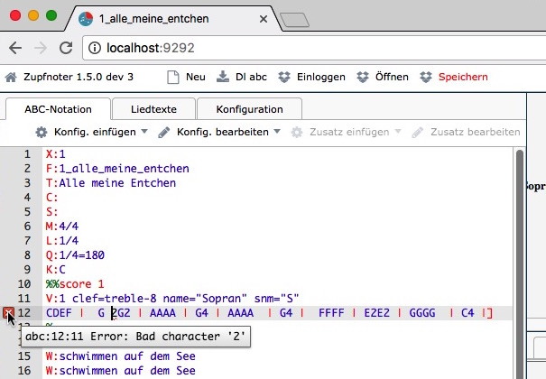

Das bedeutet in Zeile 12 an Stelle 11 ist das Zeichen ‘2’ fehlerhaft ist. Im vorliegenden Fall ist ein Leerzeichen zwischen der Tonhöhe und dem Notenwert.

Es sollten alle Fehler beseitigt werden, ansonsten können unter Umständen keine herkömmlichen Noten oder Unterlegnoten generiert werden.

> **Hinweis**: Die Position des Cursors (der Schreibmarke) wird im Format Zeile:Spalte (z.B. 12:11) ganz links in der Statusleiste angezeigt.

> **Hinweis**: Die letzten Fehlermeldungen kann man in der Konsole (mit `cmd/ctrl - K`) sehen. Nach wichtigen Befehlen zeigt Zupfnoter auch ein Fenster mit den letzten Fehlermeldungen an.

#### 4.5.1.2 Darstellung der Konfigurationsparameter im Texteditor

Nach der ABC-Notation kommen die Zupfnoter-Einstellungen. Diese werden durch den Kommentar

```
`%%%%zupfnoter.config`
```

von der ABC-Notation abgetrennt. Die ABC-Notation und die Zupfnoter-Einstellungen dürfen nicht gemischt werden.

Die Zupfnoter-Einstellungen sind in der ABC-Datei in einem standardisierten Textformat abgelegt, welches leicht lesbar und mit etwas Übung auch bearbeitbar ist (sog. JSON-Format). Dieses Format sieht eine Gruppierung und Hierarchisierung zusammenhängender Einstellungen vor.

> **Hinweis**: Zupfnoter bietet eine komfortable Benutzerführung über Bildschirmmasken zur Bearbeitung der Konfigurationsparameter, so dass die dierekte Bearbeitung im Texteditor nur noch in besonderen Fällen notwendig ist (siehe Kapitel Konfigurationsmasken).

Über die Zupfnoter-Einstellungen wird das Design der Unterlegnoten verfeinert. So können zum Beispiel repeat lines (Wiederholungslinien) besser positioniert werden oder string names (Saitennamen) eingefügt werden. Die Zupfnoter-Einstellungen können manuell eingegeben werden oder über das Menü sheet config (Blattkonfiguration) erzeugt werden. Weitere Informationen zu den Zupfnoter-Einstellungen stehen im Kapitel Konfiguration.

> **Hinweis**: Wichtig ist, nach einer Änderung in der Menüleiste immer auf auf `Rendern` (ausführen) zu drücken, damit die Unterlegnoten aktualisiert werden.

> **Hinweis**: Wenn man im Vorschaufenster Elemente mit der Maus verschiebt wird diese Änderung sofort in den Konfigurationsparametern im Textfenster gespeichert. Eine andere Ablage gibt es nicht. Daher kann man mit “Undo” (`cmd/ctrl - Z`) im Texteditor solche Änderungen auch wieder rückgängig machen. Das gilt auch für die Bearbeitung der Konfigurationsparameter über die Bildschirmmasken.

### 4.5.2 Editor für Liedtexte

Liedtexte werden in der ABC-Notation in den Kopfpzeilen `W:` erfasst. Zur Vereinfachung der Eingabe bietet Zupfnoter auch einen Liedtext-Editor Dieser ist über den Reiter `Liedtexte` erreichbar.

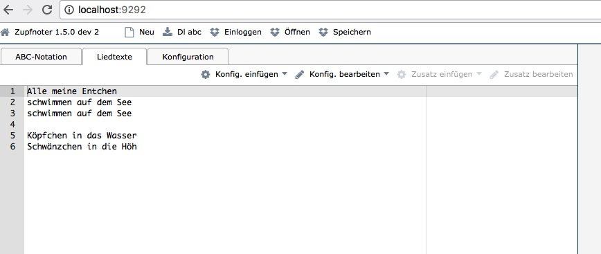

Die Texte werden beim Klick auf den Reiter `Liedtexte` aus dem Texteditor für ABC-Notation entnommen. Bei jeder Änderung werden werden die Texte sofort in den Textedtior zurückgeführt. Daher kann man die Änderungen an Texten sofort in der Notenvorschau sehen und auch aus dem Liedtexteditor `Rendern` aufrufen, um sie in der Unterlegnotenvorschau zu sehen.

> **Hinweis**: Die Anordnung der Liedtexte wird über die Konfiguration bestimmt (siehe Kapitel extract.0.lyrics

### 4.5.3 Konfigurationsmasken

Zupfnoter bietet eine komfortable Barbeitung der Konfigurationsparameter über Bildschirmmasken. Diese Masken werden über das Menu “**Konfig. bearbeiten**” aufgerufen. Die Masken wirken dann auf den aktuell eingestellten Auszug.

> **Hinweis**: Grundsätzlich bildet Zupfnoter für jeden Konfigurationsparameter einen Wert in folgender Reihenfolge
> 1. Der Wert im aktuellen Auszug bzw. im Musikstück (für Parameter die nicht pro Auszug gesetzt werden können)
> 2. wenn der aktuelle Auszug keinen Wert enthält: der Wert im Auszug 0
> 3. wenn auch der Auszug 0 keinen Wert enthält: der systeminterne Vorgabewert

Dabei gibt es zwei Arten von Masken

- vordefinierte Masken mit einem festen Aufbau. Diese zeigen Eingabefelder für Parameter auch dann, wenn sie im Musikstück noch nicht vorhanden sind. Wichtigstes Beispiel ist die Maske “Grundeinstellungen”
- dynamische Masken, welche nur die Parameter zeigen, die im Musikstück auch wirklich vorhanden sind. Prominentestes Beispiel hierfür ist die Maske “Liedtexte”

  > **Hinweis**: Es kann durchaus sinnvoll sein, über das Menü “**Konfig. einfügen**” zusätzliche Parameter hinzuzufügen, während man in einer dynamischen Maske arbeitet.

Da die Konfigurationsparameter an verschiedenen Stellen gesucht werden, muss auch das Einfügen / Löschen von Konfigurationsparametern über die Masken möglich sein. Daher gibt es in den Konfigurationsmasken pro Parameter je eine Zeile mit den folgenden Elementen:

- `Löschen` - Löscht den Paramter aus der Konfiguration

  > **Hinweis**: Diese Taste kann ggf. einen ganzen Auszug löschen (wenn man die `Löschen` - Button an einem Auszug drückt. Also sei bitte vorsichtig.
- `Füllen` - Diese Taste füllt den Parameter mit den Vorgabewerten. Falls noch nicht vorhanden wird er auch in die in die Konfiguration eingefügt (Ggf. werden auch Unterparameter mit eingefügt, z.B. bei “Layout”).
- `Name` - die Beschriftung des Parameters
- `Eingabefeld` - hier kann der Wert eingegeben werden. Bei Gruppierungen gibt es kein Eingabefeld, da hier die Werte in die Unterparameter eingetragen werden.
- `Hilfe` - zeigt eine spezifische Hilfe für diesen Parameter an
- `aktuell wirksamer Wert` - zeigt den Wert an, der für den Paramter gerade gültig ist.

  > **Hinweis**: Hier wird ggf. der Wert aus `extract.0` angezeigt falls im aktuellen Auszug noch kein Wert vorhanden ist.

  > Mit Klick auf den Knopf `Füllen` wird der Parameter in den aktuellen Auszug eingefügt und mit dem wirksamen Wert befüllt. Der Wert kann dann ggf. für diesen Auszug angepasst werden.

  > **Hinweis**: Wenn ein neuer Wert im Eingabefeld eingegebn, das Eingabefeld aber noch nicht verlassen wurde, Zeit “aktuell wirksamer Wert” noch den alten Wert an. Du musst das Eingabefeld verlassen (z.b. mit der “Tab” - Taste) um die Eingabe des Wertes abzuschließen.

[figure not shown]

Für die Bedienung der Masken ist noch wichtig

- Schaltfläche `Refresh`: Um sicher zu gehen, dass die Konfigurationsmaske wirklich die aktuellen Werte zeigt, kann mit `Refresh` die Maske neu aufgebaut werden. Dies ist z.B. dann notwendigWenn der Konfigurationsparameer außerhalb der Maske geändert wird (z.B. im Texteditor).
- Schalltfläche `Neuer Eintrag`: Diese Taste fügt eine neue Instanz eines Parameters ein. Sie ist nur aktiv, wenn es für einen Parameter mehrere Instanzen geben kann (z.B. Liedtexte [lyrics.x], Seitenbeschrifung [notes.x])
- Schalltfläche `Schnelleinstellungen`: Diese Taste öffnet ein Menü, aus dem du für die aktuelle Maske eine Voreinstellung auswählen kannst. Eine solche Voreinstellung ist eine sinnvolle Kombination von Parametern für einen bestimmten Fall (z.B. für ein “kompaktes Layout”). Diese Schaltfläche ist nur für solche Masken aktiv, für die es auch Voreinstellungen gibt.
- Feldeingabe mit der “TAB”-Taste bestätigen
- `Rendern` nicht vergessen (**In der Maske drück erst TAB, dann geht auch das “Rendern” ab**)

### 4.5.4 Masken für Zupfnoter-spezifische Zusätze

Um notenbezogene Zusatzinformation für Zupfnoter direkt zu erfassen, verwendetZupfnoter “Annotations” der ABC-Notation mit spezifischen Konventionen. Diese Zusätze stehen vor der Note bzw. dem Taktstrich auf den sie sich beziehen. Beispiel für solche Zusätze sind

- Positionierung von Sprunglinien `"^@da cape@10" C` oder `"@@4" :|`
- Verschiebung von Noten nach links/rechts `"^>!" C`
- Notenbeschriftung `"^!fine@1,1"`
- Sprungziele `"^:fine"`
- Verschiebemarken `[r: hugo]`

Zupfnoter unterstützt die Pflege diese Zusätze über Bildschirmmasken. Diese kannst du über Schaltflächen bzw. Menüs in der Werkzeugleiste des Eingabefensters aufrufen (siehe Kapitel Werkzeugleiste des Eingabefensters).

> **Hinweis**: Der Aufruf von “Zusatz einfügen” und “Zusatz bearbeiten” liegt auf unterschiedlichen Schaltflächen, da beim “Einfügen” ein Menü erscheint über welches ausgewählt wird, “was” eingefügt weden soll. Beim Bearbeiten ist diese Auswahl nicht mehr notwendig. Daher wird “bearbeiten” über eine Schaltflcähe direkt aufgerufen.

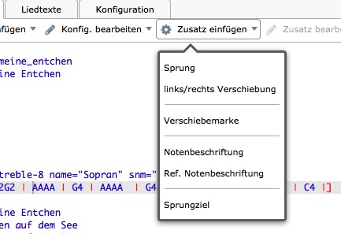

Es erscheint eine Maske nach folgendem Beispiel:

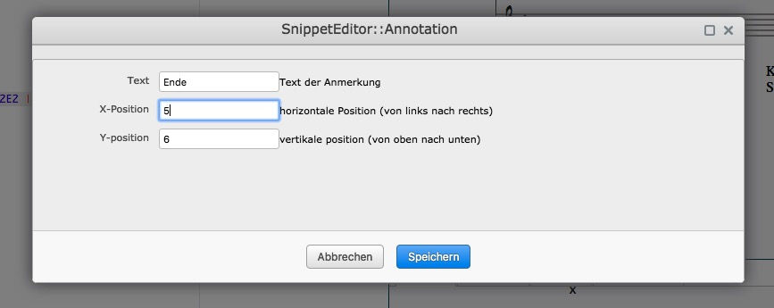

## 4.6 Erstellung von Auszügen

Zupfnoter erfasst zunächst **alle Stimmen** eines Musikstückes als umfassendes Modell. Aus diesem kompletten Modell können Auszüge erstellt werden, welche spezifische Elemente darstellen. Damit kannst du Blätter für verschiedene Zielgruppen erstellen, z.B.:

- Gesamtansicht für lektoren
- Einzelstimmen für Anfänger (z.B. nur die erste Stimme, Zählhilfen)
- Beliebige Kombinatinen von Stimmen für Leiter und Fortgeschrittene (z.B. zwei Stimmen, aber keine Zählhilfen mehr)
- verschiedene Hilfsinformationen (Zählhilfen, Taktnummern etc.)
- Sonstige Einstellungen (z.B. Druckeroptimierung usw.)

Für jeden Auszug gibt es einen Satz von Konfigurationsparameetern (`extract.0`, `extract.1`) usw. welcher den Inhalt des jeweiligen Auszuges bestimmt. Über die Schaltflcähe `Auzzug` kannst aktuell aktiven Auuszug einstellen. Der aktive Auszug bestimmt,

- was in der Unterlegnotenvorschau angezeigt wird
- auf welchen Auszug die Konfigurationsmasken wirken.

Die Auszuüge werden durchnummeriert[^12].

Der Auszug mit der **Nummer 0** hat eine besondere Rolle: Er gilt als Vorgabe für die anderen Auszuüge. Die im Auszug 0 angegebenen Werte für die Konfigurationsparameter wirken also auf die Auszüge mit höherer Nummer solange sie dort nicht überschrieben werden.

Damit kannst du im Auszug 0 die grundlegenden Einstellungen vornehmen und in den höherern Auszügen spezifische Anforderungen erfüllen.

Einstellungen, die auch im Auszug 0 nicht definiert sind, belegt Zupfnoter mit programminternen Voreinstellungen. Diese Vorgabewerte sind so, dass folgende Auszüge definiert entstehen.

- Auszug 0: Alle Stimmen
- Auszug 1: Sopran, Alt
- Auszug 2: Tenor, Bass

Dabei wird von einem vierstimmigen Satz ausgegangen und Flusslinien, Synchronsiationslinen, Stimmenauswahl etc. darauf abgestimmt.

Die folgende Abbildung illustriert das Konzept der Auszüge:

[figure not shown]

In diesem Beispiel kannst du die Zusammenhänge sehen:

> **Hinweis**: Die Angaben der auszugebenden Stimmen könnte an sich entfallen, da da sie der Voreinstellung in Zupfnoter entsprechen. Sie sind hir nur zur Illustration sufgeüfhrt.

## 4.7 Sonstige Hinweise

### 4.7.1 Wenn Zupfnoter beim Start hängen bleibt

Was ist heute schon perfekt - auch bei Zupfnoter kann es Probleme geben. In seltenen Fällen kann es vorkommen, dass die ABC-Noten oder die Konfiguration so fehlerhaft ist, dass Zupfnoter beim Start sofort in den gleichen Fehler läuft und keine Bearbeitung mehr möglich ist.

In diesem Fall kannst du beim Aufruf von Zupfnoter /?debug anhängen, z.B.

```
https://zupfnoter.weichel21.de/?debug
```

Dann startet Zupfnoter, versucht aber nicht gleich ein “Rendern” . Damit kannst dann die Eingaben korrigieren bis “Rendern” wieder funktioniert.

### 4.7.2 Transponieren

> **Hinweis**: Zupfnoter gibt die Transponierung der ersten Stimme im Unterlegnotenblatt aus. Abweichende Transpnierungen in den anderen Stimmen werden zwar ausgeführt, aber nicht vermerkt.

Dazu gibt es mit ABC 2.2 eine standardisierte Spezifikation, die ab Zupfnoter 1.6 auch umgesetzt ist.

Es würde zu weit führen hier alle Möglichkeiten darzustellen (und es sind wirklich sehr viele). Sie sind in http://abcnotation.com/wiki/abc:standard:v2.2#voice_modifiers_-_clefs_and_transposition zu finden.

- Transponierungen können nun an den Kopfzeilen `K:` und `V:`angegeben werden.
- Angaben zur Transponierung ersetzen die vorherigen Angaben

Die Angaben erfolgen über den parameter `shift=<note1><note2>`, zum Beispiel

```
V:1 shift=cd
K:c shift=cd
```

Das intervall für die Transponierung wird durch zwei Noten, `<note1>` `<note2>` angegeben. Hier bezieht sich `<note1>` auf den transkribierten abc-Code und `<note2>` bezieht sich auf die gerenderte Ausgabe.

> **Hinweis**: ABC-Notation kennt noch weitere Schlüsselworte zum Transponieren (score, sound, instrument). Es wirken sich nur die Angaben aus `shift` auf die Unterlegnoten aus, weil die Tischharfe kein transponierendes Instrument ist.

Beispiel: Im Folgenden wird die Setzpartitur von C nach G transponiert.

```
K:C shift=CG
CDE
```

is äquivalient zu

```
K:G
GAB
```

### 4.7.3 Wenn Takte nicht synchron sind

Zupfnoter prüft nicht, ob die Takte in allen Stimmen synchron sind. Wenn die Takte in den Stimmen nicht synchron sind, kommt es zu unterschiedlichen Zeilenumbrüchen und fehlerhaften Unterlegnoten.

Die Takte kann man am besten prüfen, wenn jede Stimme eine eigene Notenzeile im Notensystem hat.

Dies erreicht man mit

`%%score 1 2 3 4` Das bewirkt ein Notensystem mit einer Noteznzeile pro Stimme. Weitere Einzelheiten im nächsten Kapitel.

In diesem Zusammenhang ist es auch hilfreich, die Taktnummern einzuschalten.

Um Taktnummern in den Noten darzustellen dient die Kopfzeile

```
I:measurenb 1
```

### 4.7.4 Mehrere Stimmen in ABC-Notation

Da das im Zupfnoter-tutorial dieses Thema eher knapp behandelt ist gibt es hier weitere Informationen.

Die Kopfzeile `V:` The V: erlaubt die Erfassung mehrstimmiger Stücke. Dabei wird das Stück in Stimmen aufgeteilt. Jede Stimme beginnt mit einer `V:` - Kopfzeile. Alle Noten die dieser Zeile folgen bis zur nächsten `V:` - Kopfzeile oder dem Ende des Stückes gehören zu dieser Stimme.

Die `V:` Zeile definiert auch die Eigenschaften der Stimme mit folgendem Aufbau

> `V:<ID> [clef=]<clef name> [octave=<number>]"`

Darin ist

- `<ID>` eine Identifiaktion der Stimme, sie wird inder `%%score` - Anweisung referenziert. Es empfhiehlt sich hier einfach ganze Zahlen zu verwenden un ddie Stimme so durchzunumerieren.
- `[clef=]<clef name>` optionale Angabe des Notenschlüssels. Name ist
  - `treble` `treble+8` `treble-8` Violinschlüssel (+8 bzw. -8 verschiebt Unterlegnoten um eine Oktave)
  - `bass` `bass+8` `bass-8` Bass-Schlüssel (+8 bzw. -8) verschiebt die Unterlegnoten um eine Oktave)
- `octave=<number>` optionale Angabe einer Oktavierung. Positive Zahlen transponieren eine Oktave noch oben, negative Zahlen um eine Oktave nach unten.
- `shift=<note1><note2>` Transponiert die Stimme (siehe Kapitel Transponieren).

  > **Hinweis**: Auf den Unterlegnoten wird nur die Transponierung angegeben, die auf die erste Stimme wirkt.

Die Darstellung der Stimmen im Notensystem wird durch die `%%score` - Anweisung bestimmt. Hier einfach zwei im Zusammenhang von Zupfnoter relevante Beispiele

- `%%score 1 2 3 4` - Stimme 1,2,3,4 jeweils in einer eigenen Notenzeile
- `%%score (1 2) (3 4)` - Stimme 1, 2 bzw. 3,4 zusammengefasst in in einer Notenzeile

> **Hinweis**: In einigen Konfigurationseinstellungen von Zupfnoter werden Stimmen über eine Stimmen-Nummer angegeben. Die dabei relevante Nummerierung der Stimmem ergibt sich aus der Reihenfolge der Stimmen in der `%%score` - Anweisung im ABC-Notation (nicht zu verwecheln mit der Identifikation der Stimme in der `V:` - Zeile.

> **Hinweis**: Die ABC-Notation erlaubt mehrere `%%score` - Anweisungen. Bitte vermeide das, weil Zupfnoter dafür nicht ausgelegt ist und das Verhalten noch nicht ausgetestet ist.

### 4.7.5 Wenn die vertikale Anodrnung optimiert werden soll

Es kann vorkommen, dass man in das vertikale Layout eingreifen muss, z.B. wennd ie Flussline einer Stimme durch eine Noten einer anderen Stimme läüft. Die Möglichkeiten dazu sind in Kapitel `morinc` beschrieben.

### 4.7.6 Extra Einstellungen für die Notenvorschau

Die Notenvorschau kann durch I: oder “%%” - Zeilen beeinflusst werden. Einhelheiten siehe http://moinejf.free.fr/abcm2ps-doc/index.html

Häufige Einstellungen bei Zupfnoter sind:

- `I:measurenb 1` - schreibt Taktnummern in die Notenvorschau. Die Anzeigt ist nur dann korrekt, wennd die Takte die korrekte Länge haben.
- `I:staffnonote 2` - zeigt auch leere Notenlinien in der Notenvorschau
- `I:linewarn 0` - unterdrückt Meldungenüber nicht gefüllte oder zu volle Zeilen in der Notenvorschau

# 5 Zupfnoter für Experten

## 5.1 Zupfnoter Einstellungen

### 5.1.1 Persönliche Einstellungen

see https://github.com/bwl21/zupfnoter/issues/71

### 5.1.2 Grundlegende Blatteinstellungen (Konfiguration)

TODO: text überarbeiten

- **Titel**: [extract.x.title]

  Spezifizert den Titel des Auszugs

  > **Hinweis:** Der Titel des Auszug ist nicht zu verwechseln mit dem Titel des Musikstücks ( ABC-Kopfzeite “´T:`”)
- **Stimmen**: [extract.x.voices]

  Spezifiziert, welche Stimmen in dem Auszug dargestellt werden.
- **Flusslinien** [extract.x.flowlines]

  Spezifiziert, welche Stimmen eine Flusslinie erhalten sollen.
- **Stimmen für layout**: [extract.x.layoutlines]

  Zupfnoter errechnet die vertikale Anordnung der Noten aus den einzelnen Notenlängen. Über diese Einstellung wird bestimmt, welche Stimmen in die Berechnung eingehen.

  > **Hinweis:** man kann sogar eine eigene “Stimme” schreiben, welche nur zur Berechung des Layouts herangezogen, aber nicht auf den Unterlegnoten dargestellt wird. Auf diese Weise kann man man das layout vollständig manuell steuern.
- **Sprunglinien:** [extract.x.jumplines]

  Diese Einstellung wird bestimmt, für welche Stimmen die Sprunglinien dargestellt werden.

  Wiederholungszeichen in den herkömmlichen Noten werden in den Tisch-Harfen-Noten als Wiederholungslinie dargestellt. In der Regel muss der vertikale Teil der Wiederholungslinie nach rechts verschoben werden, damit er rechts von den Noten liegt und nicht mitten durch das Notenbild der Tisch-Harfen-Noten geht. Die horizontale Position der Sprunglinie wird über die ABC-Notation eingestellt. Dazu wird vor dem entsprechenden Taktstrich z.B. eingegeben:

  “`^@@5 :|`” - der vertikale Teil der Sprunglinie liegt fünf Halbtonschritte **rechts** von der letzten Note des Abschnittes

  “`^@@-5 :|`” - der vertikale Teil der Sprunglinie liegt fünf Halbtonschritte **links** von der letzten Note des Abschnittes
- **Synchronisationslinien:** (Synchronisationslinie, Querlinie zu Begleitnoten) [extract.x.synchlines]

  Diese Einstellung bestimmt, zwischen welchen Stimmen die Synchronisiationslinien dargestellt werden.

  **Hinweise:** Synchronisationslinien für Mehrklänge werden immer dargestellt.
- **Legende**: [extract.x.legend]

  Diese Einstellung bestimmt die Position der Legende. Dabei kann die Überschrift des Musikstückes und der Informationsblock separat positioniert werden.

  **Hinweis:** durch Veschieben der Objekte mit der Maus wird diese Einstellung automatisch eingefügt.
- **Liedtexte:** (Liedtexte) [extract.x.lyrics]

  Diese Einstellung bstimmt, wie die Liedtexte im Unterlegnotenblatt positioniert werden.

  > **Hinweis**: Zupfnoter kann nur die Liedtexte aus der Kopfzeile “`W:`” verarbeiten. In der Abc Notation kann man Liedtexte auch im Kopffeld “`w:`” erfassen, um sie innerhalb der Notenzeilen anzuordnen. Mit bestimmten Symbolen werden Wörter oder Silben den herkömmlichen Noten zugeordnet.
- **Seitenbeschriftung:** [extract.x.notes]

  TODO Sachverhalte: steht für Noten und für Notizen im Zupfnoter. Vorschlag hier umbenennen in notice oder comment???.
- **Begleitpausen:** [extact.x.nonflowrest]

  Generell werden Pausen in den Begleitnoten (Stimmen ohne Flusslinie) der herkömmlichen Noten und Tisch-Harfen-Noten unterdrückt. Wenn du die Pausen auch in den Begleitstimmen darstellen möchtest, kannst du sie mit dieser Einstellung einschalten.
- **Startposition:** [extract.x.startpos]

  Mit dieser Einstellung kann man die Startposition der Unterlegnoten festlegen. Die Angabe erfolgt in Millimeter und wird vom oberen Blattrand gemessen.
- **Unterflusslinien**: [extract.x.subflowlines]

  Diese Einstellung bestimmt, für welche Stimmen die Unterflusslinien ausgegeben werden. Dies kann sinnvoll bei Begleitnoten sein, die in der Melodie keiner Note zugeordnet werden können oder bei Verzierungsnoten.
- **Ausgabe:** [produce]

  Diese Einstellung bestimmt, welche Auszüge gedruckt werden sollen. Oft wird z.B. der Auszug 0 nur zur Bearbeitung verwendet, aber nicht gedruckt.

  Stimmen (Auszug 0 beinhaltet 100 %)
- **Layout:** (Gestaltung oder Anordnung) [extract.x.layout]
- **Zählmarken:** [extraxt.x.coountnotes]

  Es werden unter jeder Note, abhängig von der Taktart, Zahlen zugeordnet, die die Zählung des Taktes darstellen. Bei einem 4/4 Takt kann das also (1 2 3 4) oder (1 und 2 und 3 und 4 und) sein.
- **Taktnummern:** [extract.x.barnumbers]

  Diese Einstellung bestimmt, an welchen Stimmen die Takte numeriert werden. Ebenso wird Position und Darstellung bestimmt.

## 5.2 Zupfnoter-spezifische Zusätze

Zupfnoter verwendet “Annotations” der ABC-Notation mit spezifischen Konventionen. Diese Zusätze stehen vor der Note bzw. dem Taktstrich auf den sie sich beziehen.

Zupfnoter-Annotations beginnen mit einem der Zeichen `:`, `@`, `!`, `#`, `<`, `>`. Beispielwesie bedeutets `"^>"` dass das Notensymbol in den Unterlegnoten nach rechts verschoben werden.

> **Hinweis**: Dieses Zusätze können über Bildschirmmasken komfortabel bearbeitet werden (siehe Kapitel Masken für Zupfnoter-spezifische Zusätze).

Es gibt folgende Zusätze:

- **`^:`** - Sprungziel: Damit kannst du ein Ziel festelegen zu dem eine Sprunglinie gezeichnet werden kann. Damit kannst du beliebige Sprünge darstellen.
- **`^@`** - Sprung: Damit kannst du eine Sprunglinie erzeugen. Beispiele: `@p1@3`, `@@-4`
- **`^!`** - Notenbeschriftung: Damit kannst du eine Beschriftung an eine Note in den Umterlegnoten anbringen

  Beispiel:

  `"^"this is my note@5,2"` schreibt eine Beschriftung 5 mm rechts, 2mm unter die Note
- **`^#`** - Ref. Notenbeschriftung: Damit kannst du eine Beschriftung mit einem vordefinierten Text (Beschriftungsvorlage) anbringen
- **`^>`** - Rechtsverschiebung: Verschiebt das Notensymbol in den Unterlegnoten nach rechts
- **`^<`** - Linksverschiebung: Verschiebt das Notensybmol in den Unterlegnoten nach links
- **[r:n_11]** - Verschiebemarke: Das ist eine eingebettete Kopfzeile der ABC-Notation. Wenn man mit der Maus Elemente im Unterlegnotenblatt verschiebt, wird diese Verschiebung in der Konfiguration abgespeichert (`notebound`). Die Referenz wird dann über den Namen der Verschiebemarke hergestellt.

  > **Hinweis**: Wenn keine Verschiebemarke vorhanden ist, wird diese Referenz über die Zeitachse hergestellt. Daher geht diese Verbindung eventuell verloren, wenn das Zeitgefüge des Musikstückes verändert wird. Das kann durch Einfügen einer Verschiebemarke verhindert werden.

# 6 Best practice

TODO: stay tunend

- guter ton der harfennoten
- Zusammenarbeitsmodelle
- bewährte Auszüge
- Legende
  - Vorname, Nachname, Jahresangaben von Komponist, Teexter
- Abdrucksrechte
- Hinweis: bitte nicht kopieren …

# 7 ABC Tutorial

todo Penzing

# 8 Konfiguration der Ausgabe

Dieses Kapitel beschreibt die Konfiguration der Erstellung der Unterlegnotenblätter. Das Kapitel ist als Referenz aufgebaut. Die einzelnen Konfigurationsparameter werden in alphabetischer Reihenfolge aufgeführt. Bei den einzelnen Parametern wird der Text der Online-Hilfe, sowie die Voreinstellungen des Systems dargestellt.

> **Hinweis**: Auch wenn in den Bildschirmmasken die Namen der Konfigurationsparameter übersetzt sind, so basiert diese Referenz den englischen Namen.

> **Hinweis**: Manche Konfigurationsparameter können mehrfach auftreten (z.B. `extract`). In diesem Kapitel wird dann immer die Instanz mit der Nr. 0 (z.B. `extract.0`) beschrieben.

## 8.1 `annotations` - Notenbeschriftungsvorlagen

Hier kannst du eine Liste von Beschriftungsvorlagen angeben.

Zupfnoter bringt einige solcher Definitionen bereits mit.

Diese Beschriftungsvorlagen kannst du über “Zusatz einfügen” mit einer Note verbinden (Notenbeschriftung).

```
    "annotations": {
      "vl" : {"pos": [-5, -5], "text": "v"},
      "vr" : {"pos": [-1, -5], "text": "v"},
      "vt" : {"pos": [2, -5], "text": "v"}
    }
```

## 8.2 `annotations.vl` - ‘V’ links

Hier siehst du ein Beispiel für eine Notenbeschriftung (hier mit dem Namen `vl`).  
Diese dient dazu ein “V” an die Harfennote zu drucken um anzudeuten, dass die Saite nach Ablauf des Notenwertes abgedämpft werden soll.

```
    "vl": {"pos": [-5, -5], "text": "v"}
```

## 8.3 `annotations.vl.pos` - Position

Hier gibst du die Position an. Angabe erfolgt in mm als kommagetrennte Liste von horizontaler / vertikaler Position.

```
    "pos": [-5, -5]
```

## 8.4 `annotations.vl.text` - Text

Hier gibst du den Text, der ausgegeben werden soll. Dieser Text kann auch mehrzeilig sein

```
    "text": "v"
```

## 8.5 `annotations.vr` - ‘V’ rechts

TODO: Helptext für annotations.vr einfügen

```
    "vr": {"pos": [-1, -5], "text": "v"}
```

## 8.6 `annotations.vr.pos` - Position

Hier gibst du die Position an. Angabe erfolgt in mm als kommagetrennte Liste von horizontaler / vertikaler Position.

```
    "pos": [-1, -5]
```

## 8.7 `annotations.vr.text` - Text

Hier gibst du den Text, der ausgegeben werden soll. Dieser Text kann auch mehrzeilig sein

```
    "text": "v"
```

## 8.8 `annotations.vt` - ‘V’ oben

TODO: Helptext für annotations.vt einfügen

```
    "vt": {"pos": [2, -5], "text": "v"}
```

## 8.9 `annotations.vt.pos` - Position

Hier gibst du die Position an. Angabe erfolgt in mm als kommagetrennte Liste von horizontaler / vertikaler Position.

```
    "pos": [2, -5]
```

## 8.10 `annotations.vt.text` - Text

Hier gibst du den Text, der ausgegeben werden soll. Dieser Text kann auch mehrzeilig sein

```
    "text": "v"
```

## 8.11 `extract` - Auszug

Hier kannst du Auszüge für deine Unterlegnoten definieren. Das ist besonders bei mehrstimmigen Sätzen sinnvoll.

> **Hinweis**: Einstellungen im Auszug 0 wirken auf die anderen Auszüge, sofern sie dort nicht überschrieben werden.

`extract.0` spezifiziert den Auszug 0; `extract.1` spezifiziert den Auszug 1 usw.

```
    "extract": {
      "0" : {
        "barnumbers"   : {
          "autopos" : true,
          "pos"     : [6, -4],
          "prefix"  : "",
          "style"   : "small_bold",
          "voices"  : []
        },
        "countnotes"   : {
          "autopos" : true,
          "pos"     : [3, -2],
          "style"   : "smaller",
          "voices"  : []
        },
        "filenamepart" : "alle-stimmen",
        "flowlines"    : [1, 3],
        "jumplines"    : [1, 3],
        "layout"       : {
          "DRAWING_AREA_SIZE" : [400, 282],
          "ELLIPSE_SIZE"      : [3.5, 1.7],
          "LINE_MEDIUM"       : 0.3,
          "LINE_THICK"        : 0.5,
          "LINE_THIN"         : 0.1,
          "REST_SIZE"         : [4, 2],
          "limit_a3"          : true,
          "moreinc"           : {},
          "packer"            : {
            "pack_max_spreadfactor" : 2,
            "pack_method"           : 0,
            "pack_min_increment"    : 0.2
          }
        },
        "layoutlines"  : [1, 2, 3, 4],
        "legend"       : {"pos": [320, 7], "spos": [320, 27]},
        "lyrics"       : {},
        "nonflowrest"  : false,
        "notes"        : {},
        "printer"      : {
          "a3_offset"   : [0, 0],
```

[output cut: 21 more lines]

```
        "filenamepart" : "sopran-alt",
        "title"        : "Sopran, Alt",
        "voices"       : [1, 2]
      },
      "2" : {
        "filenamepart" : "tenor-bass",
        "title"        : "Tenor, Bass",
        "voices"       : [3, 4]
      },
      "3" : {
        "filenamepart" : "melodie",
        "title"        : "Melodie",
        "voices"       : [1]
      }
    }
```

## 8.12 `extract.0.barnumbers` - Taktnummern

Hier kannst du angeben, wie Taktnummern in deinem Unterlegnotenblatt ausgegeben werden sollen.

```
    "barnumbers": {
      "autopos" : true,
      "pos"     : [6, -4],
      "prefix"  : "",
      "style"   : "small_bold",
      "voices"  : []
    }
```

## 8.13 `extract.0.barnumbers.autopos` - automat. positionieren

Hier kannst du die automatische Positionierung einschalten. Dabei werden Zählmarken bzw. Taktnummern abhängig von der Größe der Noten platziert. Wenn diese Option ausgeschaltet, gelten die Werte von `pos`. Dies kann bei manchen Stücken eine sinnvollere Einstellugn sein.

Die Zählmarken/Taktnummer lassen sich weiterhin mit der Maus verschieben.

```
    "autopos": true
```

## 8.14 `extract.0.barnumbers.pos` - Position

Hier gibst du die Position an. Angabe erfolgt in mm als kommagetrennte Liste von horizontaler / vertikaler Position.

```
    "pos": [6, -4]
```

## 8.15 `extract.0.barnumbers.prefix` - Präfix

Hier kannst du einen Text angeben, der z.B. vor der Taktnummeer ausgegeben werden soll (Präfix).

```
    "prefix": ""
```

## 8.16 `extract.0.barnumbers.style` - Stil

Hier kannst du den Stil für den Text einstellen. Du hast eine Auswahl aus vordefinierten Stilen.

```
    "style": "small_bold"
```

## 8.17 `extract.0.barnumbers.voices` - Stimmen

Hier kannst du eine Liste der Stimmen angeben, die Taktnummern bekommen sollen.

```
    "voices": []
```

## 8.18 `extract.0.countnotes` - Zählmarken

Hier kannst du angeben, ob und wie Zählmarken in deinem Unterlegnotenblatt ausgegeben werden sollen.

Zählmarken sind hilfreich, um sich ein Stück erarbeiten. Sie geben Hilfestellung beim einhalten der vorgegebenen Notenweret.

```
    "countnotes": {
      "autopos" : true,
      "pos"     : [3, -2],
      "style"   : "smaller",
      "voices"  : []
    }
```

## 8.19 `extract.0.countnotes.autopos` - automat. positionieren

Hier kannst du die automatische Positionierung einschalten. Dabei werden Zählmarken bzw. Taktnummern abhängig von der Größe der Noten platziert. Wenn diese Option ausgeschaltet, gelten die Werte von `pos`. Dies kann bei manchen Stücken eine sinnvollere Einstellugn sein.

Die Zählmarken/Taktnummer lassen sich weiterhin mit der Maus verschieben.

```
    "autopos": true
```

## 8.20 `extract.0.countnotes.pos` - Position

Hier gibst du die Position an. Angabe erfolgt in mm als kommagetrennte Liste von horizontaler / vertikaler Position.

```
    "pos": [3, -2]
```

## 8.21 `extract.0.countnotes.style` - Stil

Hier kannst du den Stil für den Text einstellen. Du hast eine Auswahl aus vordefinierten Stilen.

```
    "style": "smaller"
```

## 8.22 `extract.0.countnotes.voices` - Stimmen

Hier kannst du du eine Liste - getrennt durch Komma - der Stimmen angeben, die Zählmarken bekommen sollen.

```
    "voices": []
```

## 8.23 `extract.0.filenamepart` - Filename-Zusatz

Hier kannst du einen Zusatz angeben, um welchen der Filename der PDF-Dateien für diesen Auszug ergänzt werden soll. Auf diese Weise wird jeder Auszug in einer eigenen Datei wiedergegeben.

Wenn das Feld fehlt, dann wird der Filename aus dem Inhalt von `extract.0.title` gebildet.

> **Hinweis**: Bitte achte darauf, daß jeder Auszug einen eindeutigen Filename-Zusatz oder Titel hat. Sonst werden mehrere Auszüge in die gleiche Datei geschrieben (und nur der letzte bleibt übrig).

```
    "filenamepart": "alle-stimmen"
```

## 8.24 `extract.0.flowlines` - Flußlinien

Hier kannst du du eine Liste - getrennt durch Komma - der Stimmen angeben, für die Flußlinien eingezeichnet werden sollen.

```
    "flowlines": [1, 3]
```

## 8.25 `extract.0.jumplines` - Sprunglinien

Hier kannst du du eine Liste - getrennt durch Komma - der Stimmen angeben, für die Sprunglinien eingezeichnet werden sollen.

```
    "jumplines": [1, 3]
```

## 8.26 `extract.0.layout` - Layout

Hier kannst du die Parameter für das Layout eintsllen. Damit lässt das Notenbild gezielt optimieren.

```
    "layout": {
      "DRAWING_AREA_SIZE" : [400, 282],
      "ELLIPSE_SIZE"      : [3.5, 1.7],
      "LINE_MEDIUM"       : 0.3,
      "LINE_THICK"        : 0.5,
      "LINE_THIN"         : 0.1,
      "REST_SIZE"         : [4, 2],
      "limit_a3"          : true,
      "moreinc"           : {},
      "packer"            : {
        "pack_max_spreadfactor" : 2,
        "pack_method"           : 0,
        "pack_min_increment"    : 0.2
      }
    }
```

## 8.27 `extract.0.layout.DRAWING_AREA_SIZE` - Größe der Zeichenfläche

Hier kannst du die Größe der Zeichenfläche einstellen. Allerdings hat aktuell nur die vertikale Größe einen Einfluss. Damit kann man bei großen Stücken noch ein bisschen mehr Platz ausreizen.

```
    "DRAWING_AREA_SIZE": [400, 282]
```

## 8.28 `extract.0.layout.ELLIPSE_SIZE` - Notengröße

Hier kannst du die Größe der ganzen Noten einstellen. Sinnvolle Werte sind [2-4, 1.2-2].

> **Hinweis**: Die Größe der anderen Noten werden ausgehend von diesem Wert berechnet.

> Da die Noten auch mit der dicken Linie umrandet werden, kann auch die “Linienstärke `dick`” reeduziert werden, um ein filigraneres Notenbild zu erhalten.

```
    "ELLIPSE_SIZE": [3.5, 1.7]
```

## 8.29 `extract.0.layout.LINE_MEDIUM` - Linienstärke mittel

Hier stellst du die Breite (in mm) von mittelstarken Linien ein.

```
    "LINE_MEDIUM": 0.3
```

## 8.30 `extract.0.layout.LINE_THICK` - Linienstärke dick

Hier stellst du die Breite (in mm) von dicken Linien ein.

```
    "LINE_THICK": 0.5
```

## 8.31 `extract.0.layout.LINE_THIN` - Linienstärke dünn

Hier stellst du die Breite (in mm) von dünnen Linien ein.

```
    "LINE_THIN": 0.1
```

## 8.32 `extract.0.layout.REST_SIZE` - Pausengröße

Hier kannst du die Größe der Pausen einstellen. Sinnvolle Werte sind [2-4, 1.2-2]

> **Hinweis**:Bitte beachte, dass nur die Angabe der Höhe von berücksichtigt wird, da das Pausensymbol nicht verzerrt werden darf.

```
    "REST_SIZE": [4, 2]
```

## 8.33 `extract.0.layout.limit_a3` - Begrenzung auf A3

Diese Funktion verschiebt Noten am A3-Blattrand nach innen. Da das Unterlegnotenblatt etwas größer ist als A3 würde sonst die Note angeshnitten.

```
    "limit_a3": true
```

## 8.34 `extract.0.layout.moreinc` - extra Vorschub

Hier kannst du manuelle Korrekturen im vertikalen Layout vornehmen:

> **Hinweis**: Diese Funktion ist nun wirklich für die ganzen Experten. Bitte verwende sie also nur, wenn du weißt, was du tust. Anwendungsfälle für diese Funktion:
> - Linien (z.B. Sprunglinien) gehen unglücklich durch andere Noten oder Beschriftungen
> - Bei sehr dichten Layouts gehen Taktstriche in die vorherige Note
> - Man hat sehr viele Noten, könnte aber einen Teil in eine freie Fläche schieben. In diesem fall würde die Flusslinie teilweise nach oben gehen.

Dieser Parameter enthält eine Liste manuellen Layoutkorrekturen. Jeder eintrag ist ein Feld mit Notenlabel und Vorschubwert.

- **Notenlabel**: kannst du rechts unten sehen, wenn du mit der Maus auf die Note fährst. Am besten ist es eine “Verschiebemarke” vor der betroffenen Note anzubrigen.
- **Verschiebewert**: Dieser Wert ist ein vielfaches des normalen Vorschubs und wird hinzugefügt. Zum Beispiel wird duch “1.0” der Vorschub verdoppelt. “-1.0” würde den Vorschub auf 0 setzen.

  ```
  "moreinc": {}
  ```

## 8.35 `extract.0.layout.packer` - Packer

Hier kannst du weitere Einzelheiten für die vertikale Anordnung der Noten konfigurieren. Es sind subtile Feinheiten, welche den Unterschied ausmachen. Daher sind diese Funktionen noch experimentell.

```
    "packer": {
      "pack_max_spreadfactor" : 2,
      "pack_method"           : 0,
      "pack_min_increment"    : 0.2
    }
```

## 8.36 `extract.0.layout.packer.pack_max_spreadfactor` - max. Spreizung

Nach der Berechnung des maximal komprimierten Layouts versucht Zufpnoter, dieses so weit zu spreizen, dass die Zeichenfläche voll ausgefüllt wird.

Dieser Faktor bestimmt, wie weit das maximal komprimierte Layout in der Vertikalen gespreizt werden soll. Das wirkt sich bei kurzen Stücken aus, welche das Blatt nicht vollständig ausfüllen.

Bei sehr kurzen Stücken ist es sinnvoll, die Spreizung zu begrenzen, weil sonst die Noten sehr weit auseinander liegen.

```
    "pack_max_spreadfactor": 2
```

## 8.37 `extract.0.layout.packer.pack_method` - Packmethode

Hier kannst du die pack-Methode auswählen

- **0** : Die bisherige Methode: diese geht nach jedem Schrift um die Höhe der größten Note weiter
- **1** : Kopmpakt: diese geht nur dann weiter, wenn
  - ein Richtungswechsel der Melodie vorliegt
  - Noten übereinander gezeichnet würden

  Das bedeutet dass bei monotonen Melodien die Noten enger gesetzt werden.

  > **Hinweis**: Diese Methode eignet sich am besten für lange, einstimmige Stücke. Die Platzeinsparung geht bei mehrstimmmigen Stücken schnell verloren. Bei dieser Methode sind die Synchronisiationslinien nicht immer gut sichtbar.

  ```
  "pack_method": 0
  ```

## 8.38 `extract.0.layout.packer.pack_min_increment` - min. Inkrement

Dieser Faktor bstimmt, wie weit pro Note auf jeden Fall weiter gerückt wird. Pro Note wird mindestens um diesen Anteil einer Maximalnote weiter geschaltet.

Beispiele:

- **0.0**: es entstehen horizontale Flußlinien
- **1.0**: es wird mindests um eine ganze Note weiter geschaltet
- **0.2**: es wird um 20% einer ganzen Note weiter geschaltet. Dies liefert angenehme Ergebnisse.

  ```
  "pack_min_increment": 0.2
  ```

## 8.39 `extract.0.layoutlines` - Stimmen für Layout

Hier kannst du du eine Liste - getrennt durch Komma - der Stimmen angeben, die zur die Berechnung des vertikalen Anordnugn der Noten (Layout) herangezogen werden sollen.

Üblicherweise werden alle Stimmen für die Berechnung des Layouts herangezogen. Bei langen Stücken kann es aber sinnvoll sein, nur die dargstellten Stimmmen zur Berechnung des Layouts zu berücksichtigen, um ein ausgwogeneres Notenbild zu bekommen.

> **Hinweis**: Auch wenn der Parameter `layoutlines` heißt, bewirkt er nicht, dass irgendwelche Linien eingezeichnet werden.

> **Hinweis**: Bei einem Stück mit vielen Noten ist es sinnvoll, hier nur die im aktuellen Auszug dargestellten Stimmen aufzulisten. Damit ist zwar das Notenbild nicht mehr bei allen Auszügen gleich, die Noten sind aber besser verteilt.

```
    "layoutlines": [1, 2, 3, 4]
```

## 8.40 `extract.0.legend` - Legende

Hier kannst du die Darstellung der Legende konfigurieren. Dabei wird unterschieden zwischen

- `pos` - Position des Titels des Musikstückes
- `spos` - Position der Sublegende, d.h. der weiteren Angaben zum Musikstück

> **Hinweis**: Die Legende wird vorzugsweise durch Verschieben mit der Maus positioniert. Für eine genaue positionierung kann jedoch die Eingabe über die Bildschirmmaske sinnvol sein.

```
    "legend": {"pos": [320, 7], "spos": [320, 27]}
```

## 8.41 `extract.0.legend.pos` - Position

Hier kannst du die Darstellung des Titels des Musikstückes angeben. Die Angabe erfolgt in mm als kommagetrennte Liste von horizontaler / vertikaler Position.

```
    "pos": [320, 7]
```

## 8.42 `extract.0.legend.spos` - Position Sublegende

Hier kannst du die Darstellung der weiteren Angaben (Sublegende) des Musikstückes angeben. Die Angabe erfolgt in mm als kommagetrennte Liste von horizontaler / vertikaler Position.

```
    "spos": [320, 27]
```

## 8.43 `extract.0.lyrics` - Liedtexte

Hier steuerst du die Positionierung der Liedtexte. Dabei kannst du den Liedtext auf mehrer Blöcke aufteilen.

Ein einzelner Block listet die Strophen auf, die er enthält, und die gemeinsam poitioniert werden.

```
    "lyrics": {}
```

## 8.44 `extract.0.nonflowrest` - Begleitpausen

Hier kannst du einstellen, ob in den Begleitstimmen ebenfalls die Pausen dargestellt werden sollen. Eine Stimme wird dann Begleitstimme betrachtet, wenn sie keine Flußlinie hat.

Normalerweise ist es nicht sinnvoll, in den Begleitstimmen Pausen darzustellen, da der Spieler sich ja an den Pausen in der Flußlinie orientiert.

```
    "nonflowrest": false
```

## 8.45 `extract.0.notes` - Seitenbeschriftungen

Hier kannst du eine Seitenbeschriftungen hinzufügen. Beim Einfügen einer Seitenbeschriftung vergibt Zupfnoter eine Nummer anstelle der `.0`.

> **Hinweis**: Es kann aber auch sinnvoll sein eine sprechende Bezeichnung für die Beschriftung manuell vorzugeben um ihrer spezifische Verwendung hervorzuheben z.B. `notes.T_Copyright`. Das ist allerdings nur in der Textansicht möglich.

```
    "notes": {}
```

## 8.46 `extract.0.printer` - Drucker

Hier kannst du das Druckbild auf deine Drucher-Umgebung anpassen.

> **Hinweis:** Durch Verwendung dieser Funktion passen die erstellten PDF-Dateien eventuell nicht mehr auf andere Umgebungen. Bitte verwende die Funktion also erst, wenn du keine geeigneten Einstellungen in deinem Druckdialog findest.

```
    "printer": {
      "a3_offset"   : [0, 0],
      "a4_offset"   : [-5, 0],
      "show_border" : false
    }
```

## 8.47 `extract.0.printer.a3_offset` - Offset für A3

Hier defnierst du, wie das Druckbild beim Ausdruck auf A3-Papier verschoben werden soll.

Angabe erfolgt in mm als kommagetrennte Liste von horizontaler / vertikaler Position.

> **Hinweis**: Wenn ein Unterlegnotenblatt für eine 25 saitige Harfe auf ein A3-Blatt gedruckt wird, ist es sinnvoll, das Druckbild um 10 mm nach links zu verschieben. Dadurch werden die Noten vom Drucker nicht mehr angeschnitten.

> In diesem Fall kann es auch sinnvoll sein, `limit-A3` auszuschalten.

```
    "a3_offset": [0, 0]
```

## 8.48 `extract.0.printer.a4_offset` - Offset für A4

Hier defnierst du, wie das Druckbild beim Ausdruck auf A3-Papier verschoben werden soll.

Angabe erfolgt in mm als kommagetrennte Liste von horizontaler / vertikaler Position.

```
    "a4_offset": [-5, 0]
```

## 8.49 `extract.0.printer.show_border` - Blattbegrenzg. zeichnen

Hier kannst du einstellen, ob die Blattbegrenzung gedruckt werden soll. Die Blattbegrenzung liegt eigntlich ausserhalb des Bereiches, den der Drucker auf dem Papier bedrucken kann. Wenn der Drucker das Druckbild auf dem Papier zentriert, ist die Blattbegrenzung nicht sichtbar. Ihre Darstellung auf der Druckvorschau kann trotzdem hilfreich sein.

Manche Drucker positionieren das Druckbild aber nicht zentriert auf dem Papier. Dadurch wird die Blattbegrenzung gedruckt, dafür fehlen dann unten ca. 10 mm.

Versuche in diesem Fall, ob das Ausschalten der Blattbegrenzung die Situation verbessert.

```
    "show_border": false
```

## 8.50 `extract.0.repeatsigns` - Wiederholungszeichen

Hier kannst du die Darstellung der Wiederholungszeichen steuern. Dabei wird angegeben, für welche Stimmen Wiederholgungszeichen gedruckt werden, wie die Wiederholungszeichen gedruckt werden, und wie sie positioniert werden.

```
    "repeatsigns": {
      "left"   : {"pos": [-7, -2], "style": "bold", "text": "|:"},
      "right"  : {"pos": [5, -2], "style": "bold", "text": ":|"},
      "voices" : []
    }
```

## 8.51 `extract.0.repeatsigns.left` - links

Hier kannst du die Darstellung des linken Wiederholungszeichen steuern.

```
    "left": {"pos": [-7, -2], "style": "bold", "text": "|:"}
```

## 8.52 `extract.0.repeatsigns.left.pos` - Position

Hier gibst du die Position an. Angabe erfolgt in mm als kommagetrennte Liste von horizontaler / vertikaler Position.

```
    "pos": [-7, -2]
```

## 8.53 `extract.0.repeatsigns.left.style` - Stil

Hier kannst du den Stil für den Text einstellen. Du hast eine Auswahl aus vordefinierten Stilen.

```
    "style": "bold"
```

## 8.54 `extract.0.repeatsigns.left.text` - Text

Hier gibst du den Text an, der als linkes Wiederholungszeichen ausgegeben werden soll.

```
    "text": "|:"
```

## 8.55 `extract.0.repeatsigns.right` - rechts

Hier kannst du die Darstellung des rechten Wiederholungszeichen steuern.

```
    "right": {"pos": [5, -2], "style": "bold", "text": ":|"}
```

## 8.56 `extract.0.repeatsigns.right.pos` - Position

Hier gibst du die Position an. Angabe erfolgt in mm als kommagetrennte Liste von horizontaler / vertikaler Position.

```
    "pos": [5, -2]
```

## 8.57 `extract.0.repeatsigns.right.style` - Stil

Hier kannst du den Stil für den Text einstellen. Du hast eine Auswahl aus vordefinierten Stilen.

```
    "style": "bold"
```

## 8.58 `extract.0.repeatsigns.right.text` - Text

Hier gibst du den Text an, der als rechtes Wiederholungszeichen ausgegeben werden soll.

```
    "text": ":|"
```

## 8.59 `extract.0.repeatsigns.voices` - Stimmen

Hier gibst du eine Liste (durch Komma getrenn) der Stimmen and, für welche Wiederholungszeichen anstelle von Sprunglinie ausgegeben werden.

> Hinweis: Zupnoter stellt für die hier aufgelisteten Stimmen keine Sprunglinien mehr dar.

```
    "voices": []
```

## 8.60 `extract.0.startpos` - Startposition

Hier kannst du die Position von oben angeben, an welcher die Harfennoten beinnen. Damit kannst du ein ausgewogeneres Bild erhalten.

> **Hinweis**:Durch diese Funktion wird auch der Bereich verkleinert, in dem die Noten dargestellt werden. Sie ist daher vorzugsweise bei kurzen Stücken anzuwenden, die sonst oben auf der Seite hängen.

```
    "startpos": 15
```

## 8.61 `extract.0.stringnames` - Saitennamen

Hier kannst du stueern, ob und wie Saitennamen auf das Unterlegnotenblatt gedruckt werden.

```
    "stringnames": {
      "marks" : {"hpos": [43, 55, 79], "vpos": [11]},
      "style" : "small",
      "text"  : "G G# A A# B C C# D D# E F F# G G# A A# B C C# D D# E F F# G G# A A# B C C# D D# E F F# G",
      "vpos"  : []
    }
```

## 8.62 `extract.0.stringnames.marks` - Saitenmarken

Hier kannst du angeben, ob und wo Saitenmarken gedruckt werden.

```
    "marks": {"hpos": [43, 55, 79], "vpos": [11]}
```

## 8.63 `extract.0.stringnames.marks.hpos` - horizontale Position

Hier gibst du die horizontale Position der Saitenmarken an. Die Angabe ist eine durch Komma getrennte liste von Midi-Pitches.

Die Angabe `[43, 55, 79]` druckt Saitenmarken bei `G, G, g'`. also bei den äußeren G-Saiten der 25-saitigen bzw. der 37-saitigen Tischharfe.

```
    "hpos": [43, 55, 79]
```

## 8.64 `extract.0.stringnames.marks.vpos` - vertikale Position

Hier gibst du einen Abstand vom oberen Blattrand. Die Angabe erfolgt in mm.

```
    "vpos": [11]
```

## 8.65 `extract.0.stringnames.style` - Stil

Hier kannst du den Stil für den Text einstellen. Du hast eine Auswahl aus vordefinierten Stilen.

```
    "style": "small"
```

## 8.66 `extract.0.stringnames.text` - Text

Hier gibst du die Liste der Saitennamen getrennt druch Leerzeichen an. Die Liste wird so oft zusamengefügt, dass alle Saiten einen Nanen bekommen.

In der Regel reicht es also, die Saitennamen für eine Oktave anzugeben.

**Beispiel:**

  ```
  "text": "G G# A A# B C C# D D# E F F# G G# A A# B C C# D D# E F F# G G# A A# B C C# D D# E F F# G"
  ```

## 8.67 `extract.0.stringnames.vpos` - vertikale Position

Hier gibst du einen Abstand vom oberen Blattrand. Die Angabe erfolgt in mm.

```
    "vpos": []
```

## 8.68 `extract.0.subflowlines` - Hilfsmelodielinien

Hier kannst du du eine Liste - getrennt durch Komma - der Stimmen angeben, für die Unterflußlinien eingezeichnet werden sollen.

```
    "subflowlines": [2, 4]
```

## 8.69 `extract.0.synchlines` - Synchronisationslinien

Hier kannst du angeben, welche Stimmenpaare über Synchronisationslinien verbunden werden sollen.

Die Angabe erfolgt in der Bildschirmmaske als eine durch Komma separierte Liste von Stimmenpaaren (darin die Stimmen durch “-” getrennt).

Die Angabe “`1-2, 3-4`” bedeutet beispielsweise, dass zwischen den Stimmen 1 und 2 bzw. den Stimmen 3 und 4 eine Synchronisationslinie gezeichnet werden soll.

> **Hinweis**:In der Texteingabe wird das als eine Liste von zweiwertigen Listen dargestellt.

```
    "synchlines": [[1, 2], [3, 4]]
```

## 8.70 `extract.0.title` - Titel

Hier spezifizierst du den Titel des Auszuges. Er wird in der Legende mit ausgegeben.

> **Hinweis**: Der Titel des Auszuges wird an die Angabe in der Zeile “F:” angehängt, falls nicht noch ein `extract.0.filenamepart` spezifiziert ist.

```
    "title": "alle Stimmen"
```

## 8.71 `extract.0.voices` - Stimmen

Hier gibst du eine Liste von Sstimmen als (durch Komma getrennte) Liste von Nummern an. Die Nummer ergibt sich aus der Reihnfolge in der `%%score` - Anweisung in der ABC-Notation.

```
    "voices": [1, 2, 3, 4]
```

## 8.72 `presets` - Vorlagen

TODO: Helptext für presets einfügen

```
    "presets": {
      "layout"  : {
        "layout_compact" : {
          "ELLIPSE_SIZE" : [3.5, 1.3],
          "LINE_MEDIUM"  : 0.2,
          "LINE_THICK"   : 0.3,
          "REST_SIZE"    : [4, 1.5]
        },
        "layout_large"   : {
          "ELLIPSE_SIZE" : [4, 2],
          "LINE_MEDIUM"  : 0.3,
          "LINE_THICK"   : 0.7,
          "REST_SIZE"    : [4, 2]
        },
        "layout_regular" : "#<Proc:0x007ffbd402bb60@/Users/beweiche/beweiche_noTimeMachine/200_zupfnoter/30_sources/SRC_Zupfnoter/src/init_conf.rb:76 (lambda)>"
      },
      "notes"   : {
        "T01_number"               : {
          "value" : {"pos": [393, 17], "style": "bold", "text": "XXX-999"}
        },
        "T01_number_extract"       : {
          "value" : {"pos": [411, 17], "style": "bold", "text": "-X"}
        },
        "T01_number_extract_value" : {"key": "T01_number_extract", "value": {"text": "-X"}},
        "T02_copyright_music"      : {
          "value" : {
            "pos"   : [340, 251],
            "style" : "small",
            "text"  : "© 2017\n"
          }
        },
        "T03_copyright_harpnotes"  : {
          "value" : {
            "pos"   : [340, 260],
            "style" : "small",
            "text"  : "© 2017 Notenbild: zupfnoter.de"
          }
        },
        "T04_to_order"             : {
          "value" : {"pos": [340, 242], "style": "small", "text": null}
```

[output cut: 21 more lines]

```
            "a3_offset"   : [-10, 0],
            "a4_offset"   : [-5, 0],
            "show_border" : false
          }
        },
        "printer_right"   : {
          "layout"  : {"limit_a3": false},
          "printer" : {
            "a3_offset"   : [10, 0],
            "a4_offset"   : [5, 0],
            "show_border" : false
          }
        }
      }
    }
```

## 8.73 `presets.layout` - Layout

Hier kannst du die Parameter für das Layout eintsllen. Damit lässt das Notenbild gezielt optimieren.

```
    "layout": {
      "layout_compact" : {
        "ELLIPSE_SIZE" : [3.5, 1.3],
        "LINE_MEDIUM"  : 0.2,
        "LINE_THICK"   : 0.3,
        "REST_SIZE"    : [4, 1.5]
      },
      "layout_large"   : {
        "ELLIPSE_SIZE" : [4, 2],
        "LINE_MEDIUM"  : 0.3,
        "LINE_THICK"   : 0.7,
        "REST_SIZE"    : [4, 2]
      },
      "layout_regular" : "#<Proc:0x007ffbd402bb60@/Users/beweiche/beweiche_noTimeMachine/200_zupfnoter/30_sources/SRC_Zupfnoter/src/init_conf.rb:76 (lambda)>"
    }
```

## 8.74 `presets.layout.layout_compact` - Kompaktes Layout

TODO: Helptext für presets.layout.layout_compact einfügen

```
    "layout_compact": {
      "ELLIPSE_SIZE" : [3.5, 1.3],
      "LINE_MEDIUM"  : 0.2,
      "LINE_THICK"   : 0.3,
      "REST_SIZE"    : [4, 1.5]
    }
```

## 8.75 `presets.layout.layout_compact.ELLIPSE_SIZE` - Notengröße

Hier kannst du die Größe der ganzen Noten einstellen. Sinnvolle Werte sind [2-4, 1.2-2].

> **Hinweis**: Die Größe der anderen Noten werden ausgehend von diesem Wert berechnet.

> Da die Noten auch mit der dicken Linie umrandet werden, kann auch die “Linienstärke `dick`” reeduziert werden, um ein filigraneres Notenbild zu erhalten.

```
    "ELLIPSE_SIZE": [3.5, 1.3]
```

## 8.76 `presets.layout.layout_compact.LINE_MEDIUM` - Linienstärke mittel

TODO: Helptext für presets.layout.layout_compact.LINE_MEDIUM einfügen

```
    "LINE_MEDIUM": 0.2
```

## 8.77 `presets.layout.layout_compact.LINE_THICK` - Linienstärke dick

TODO: Helptext für presets.layout.layout_compact.LINE_THICK einfügen

```
    "LINE_THICK": 0.3
```

## 8.78 `presets.layout.layout_compact.REST_SIZE` - Pausengröße

Hier kannst du die Größe der Pausen einstellen. Sinnvolle Werte sind [2-4, 1.2-2]

> **Hinweis**:Bitte beachte, dass nur die Angabe der Höhe von berücksichtigt wird, da das Pausensymbol nicht verzerrt werden darf.

```
    "REST_SIZE": [4, 1.5]
```

## 8.79 `presets.layout.layout_large` - Großes Layout

TODO: Helptext für presets.layout.layout_large einfügen

```
    "layout_large": {
      "ELLIPSE_SIZE" : [4, 2],
      "LINE_MEDIUM"  : 0.3,
      "LINE_THICK"   : 0.7,
      "REST_SIZE"    : [4, 2]
    }
```

## 8.80 `presets.layout.layout_large.ELLIPSE_SIZE` - Notengröße

Hier kannst du die Größe der ganzen Noten einstellen. Sinnvolle Werte sind [2-4, 1.2-2].

> **Hinweis**: Die Größe der anderen Noten werden ausgehend von diesem Wert berechnet.

> Da die Noten auch mit der dicken Linie umrandet werden, kann auch die “Linienstärke `dick`” reeduziert werden, um ein filigraneres Notenbild zu erhalten.

```
    "ELLIPSE_SIZE": [4, 2]
```

## 8.81 `presets.layout.layout_large.LINE_MEDIUM` - Linienstärke mittel

TODO: Helptext für presets.layout.layout_large.LINE_MEDIUM einfügen

```
    "LINE_MEDIUM": 0.3
```

## 8.82 `presets.layout.layout_large.LINE_THICK` - Linienstärke dick

TODO: Helptext für presets.layout.layout_large.LINE_THICK einfügen

```
    "LINE_THICK": 0.7
```

## 8.83 `presets.layout.layout_large.REST_SIZE` - Pausengröße

Hier kannst du die Größe der Pausen einstellen. Sinnvolle Werte sind [2-4, 1.2-2]

> **Hinweis**:Bitte beachte, dass nur die Angabe der Höhe von berücksichtigt wird, da das Pausensymbol nicht verzerrt werden darf.

```
    "REST_SIZE": [4, 2]
```

## 8.84 `presets.layout.layout_regular` - Normales Layout

TODO: Helptext für presets.layout.layout_regular einfügen

```
    "layout_regular": "#<Proc:0x007ffbd402bb60@/Users/beweiche/beweiche_noTimeMachine/200_zupfnoter/30_sources/SRC_Zupfnoter/src/init_conf.rb:76 (lambda)>"
```

## 8.85 `presets.notes` - Seitenbeschriftungen

Hier kannst du eine Seitenbeschriftungen hinzufügen. Beim Einfügen einer Seitenbeschriftung vergibt Zupfnoter eine Nummer anstelle der `.0`.

> **Hinweis**: Es kann aber auch sinnvoll sein eine sprechende Bezeichnung für die Beschriftung manuell vorzugeben um ihrer spezifische Verwendung hervorzuheben z.B. `notes.T_Copyright`. Das ist allerdings nur in der Textansicht möglich.

```
    "notes": {
      "T01_number"               : {
        "value" : {"pos": [393, 17], "style": "bold", "text": "XXX-999"}
      },
      "T01_number_extract"       : {
        "value" : {"pos": [411, 17], "style": "bold", "text": "-X"}
      },
      "T01_number_extract_value" : {"key": "T01_number_extract", "value": {"text": "-X"}},
      "T02_copyright_music"      : {
        "value" : {
          "pos"   : [340, 251],
          "style" : "small",
          "text"  : "© 2017\n"
        }
      },
      "T03_copyright_harpnotes"  : {
        "value" : {
          "pos"   : [340, 260],
          "style" : "small",
          "text"  : "© 2017 Notenbild: zupfnoter.de"
        }
      },
      "T04_to_order"             : {
        "value" : {"pos": [340, 242], "style": "small", "text": null}
      },
      "T99_do_not_copy"          : {
        "value" : {"pos": [380, 284], "style": "small_bold", "text": null}
      }
    }
```

## 8.86 `presets.notes.T01_number` - T01 Nummer

TODO: Helptext für presets.notes.T01_number einfügen

```
    "T01_number": {
      "value" : {"pos": [393, 17], "style": "bold", "text": "XXX-999"}
    }
```

## 8.87 `presets.notes.T01_number.value` - Wert

TODO: Helptext für presets.notes.T01_number.value einfügen

```
    "value": {"pos": [393, 17], "style": "bold", "text": "XXX-999"}
```

## 8.88 `presets.notes.T01_number.value.pos` - Position

Hier gibst du die Position an. Angabe erfolgt in mm als kommagetrennte Liste von horizontaler / vertikaler Position.

```
    "pos": [393, 17]
```

## 8.89 `presets.notes.T01_number.value.style` - Stil

Hier kannst du den Stil für den Text einstellen. Du hast eine Auswahl aus vordefinierten Stilen.

```
    "style": "bold"
```

## 8.90 `presets.notes.T01_number.value.text` - Text

Hier gibst du den Text, der ausgegeben werden soll. Dieser Text kann auch mehrzeilig sein

```
    "text": "XXX-999"
```

## 8.91 `presets.notes.T01_number_extract` - T01 Auszug-Nummer

Dieses Template fügt zwei Zeichem am Ende der Nummer an. Damit kann man den jeweiligen Auszug kennzeichen.

Ein sinnvolles schema ist:

  ```
  "T01_number_extract": {"value": {"pos": [411, 17], "style": "bold", "text": "-X"}}
  ```

## 8.92 `presets.notes.T01_number_extract.value` - Wert

TODO: Helptext für presets.notes.T01_number_extract.value einfügen

```
    "value": {"pos": [411, 17], "style": "bold", "text": "-X"}
```

## 8.93 `presets.notes.T01_number_extract.value.pos` - Position

Hier gibst du die Position an. Angabe erfolgt in mm als kommagetrennte Liste von horizontaler / vertikaler Position.

```
    "pos": [411, 17]
```

## 8.94 `presets.notes.T01_number_extract.value.style` - Stil

Hier kannst du den Stil für den Text einstellen. Du hast eine Auswahl aus vordefinierten Stilen.

```
    "style": "bold"
```

## 8.95 `presets.notes.T01_number_extract.value.text` - Text

Hier gibst du den Text, der ausgegeben werden soll. Dieser Text kann auch mehrzeilig sein

```
    "text": "-X"
```

## 8.96 `presets.notes.T01_number_extract_value` - T01 Auszugn Nummer Wert

TODO: Helptext für presets.notes.T01_number_extract_value einfügen

```
    "T01_number_extract_value": {"key": "T01_number_extract", "value": {"text": "-X"}}
```

## 8.97 `presets.notes.T01_number_extract_value.key` - schlüssel

TODO: Helptext für presets.notes.T01_number_extract_value.key einfügen

```
    "key": "T01_number_extract"
```

## 8.98 `presets.notes.T01_number_extract_value.value` - Wert

TODO: Helptext für presets.notes.T01_number_extract_value.value einfügen

```
    "value": {"text": "-X"}
```

## 8.99 `presets.notes.T01_number_extract_value.value.text` - Text

Hier gibst du den Text, der ausgegeben werden soll. Dieser Text kann auch mehrzeilig sein

```
    "text": "-X"
```

## 8.100 `presets.notes.T02_copyright_music` - T02 Copyright Musik

Dieses Template fügt einen Copyrightvermerk für die Musik ein. Hier wird das Copyright auf die Komposition angegeben.

```
    "T02_copyright_music": {
      "value" : {"pos": [340, 251], "style": "small", "text": "© 2017\n"}
    }
```

## 8.101 `presets.notes.T02_copyright_music.value` - Wert

TODO: Helptext für presets.notes.T02_copyright_music.value einfügen

```
    "value": {"pos": [340, 251], "style": "small", "text": "© 2017\n"}
```

## 8.102 `presets.notes.T02_copyright_music.value.pos` - Position

Hier gibst du die Position an. Angabe erfolgt in mm als kommagetrennte Liste von horizontaler / vertikaler Position.

```
    "pos": [340, 251]
```

## 8.103 `presets.notes.T02_copyright_music.value.style` - Stil

Hier kannst du den Stil für den Text einstellen. Du hast eine Auswahl aus vordefinierten Stilen.

```
    "style": "small"
```

## 8.104 `presets.notes.T02_copyright_music.value.text` - Text

Hier gibst du den Text, der ausgegeben werden soll. Dieser Text kann auch mehrzeilig sein

```
    "text": "© 2017\n"
```

## 8.105 `presets.notes.T03_copyright_harpnotes` - T03 Copyright Unterlegnoten

Dieses Template fügt einen Copyrightvermerk für das Unterlgnotenbild ein. Damit reklamierst du ein Copyright für die Umsetzung auf die Tischharfe

```
    "T03_copyright_harpnotes": {
      "value" : {
        "pos"   : [340, 260],
        "style" : "small",
        "text"  : "© 2017 Notenbild: zupfnoter.de"
      }
    }
```

## 8.106 `presets.notes.T03_copyright_harpnotes.value` - Wert

TODO: Helptext für presets.notes.T03_copyright_harpnotes.value einfügen

```
    "value": {
      "pos"   : [340, 260],
      "style" : "small",
      "text"  : "© 2017 Notenbild: zupfnoter.de"
    }
```

## 8.107 `presets.notes.T03_copyright_harpnotes.value.pos` - Position

Hier gibst du die Position an. Angabe erfolgt in mm als kommagetrennte Liste von horizontaler / vertikaler Position.

```
    "pos": [340, 260]
```

## 8.108 `presets.notes.T03_copyright_harpnotes.value.style` - Stil

Hier kannst du den Stil für den Text einstellen. Du hast eine Auswahl aus vordefinierten Stilen.

```
    "style": "small"
```

## 8.109 `presets.notes.T03_copyright_harpnotes.value.text` - Text

Hier gibst du den Text, der ausgegeben werden soll. Dieser Text kann auch mehrzeilig sein

```
    "text": "© 2017 Notenbild: zupfnoter.de"
```

## 8.110 `presets.notes.T04_to_order` - T04 zu beziehen bei

Dieses Template fügt eine Notiz ein wo man das Unterlegnotenblatt beziehen kann. Das ist sinnvoll, wenn die Unterlegoten in irgendeiner Weise vertrieben werden.

```
    "T04_to_order": {
      "value" : {"pos": [340, 242], "style": "small", "text": null}
    }
```

## 8.111 `presets.notes.T04_to_order.value` - Wert

TODO: Helptext für presets.notes.T04_to_order.value einfügen

```
    "value": {"pos": [340, 242], "style": "small", "text": null}
```

## 8.112 `presets.notes.T04_to_order.value.pos` - Position

Hier gibst du die Position an. Angabe erfolgt in mm als kommagetrennte Liste von horizontaler / vertikaler Position.

```
    "pos": [340, 242]
```

## 8.113 `presets.notes.T04_to_order.value.style` - Stil

Hier kannst du den Stil für den Text einstellen. Du hast eine Auswahl aus vordefinierten Stilen.

```
    "style": "small"
```

## 8.114 `presets.notes.T04_to_order.value.text` - Text

Hier gibst du den Text, der ausgegeben werden soll. Dieser Text kann auch mehrzeilig sein

```
    "text": null
```

## 8.115 `presets.notes.T99_do_not_copy` - T99 bitte nicht kopieren

TODO: Helptext für presets.notes.T99_do_not_copy einfügen

```
    "T99_do_not_copy": {
      "value" : {"pos": [380, 284], "style": "small_bold", "text": null}
    }
```

## 8.116 `presets.notes.T99_do_not_copy.value` - Wert

TODO: Helptext für presets.notes.T99_do_not_copy.value einfügen

```
    "value": {"pos": [380, 284], "style": "small_bold", "text": null}
```

## 8.117 `presets.notes.T99_do_not_copy.value.pos` - Position

Hier gibst du die Position an. Angabe erfolgt in mm als kommagetrennte Liste von horizontaler / vertikaler Position.

```
    "pos": [380, 284]
```

## 8.118 `presets.notes.T99_do_not_copy.value.style` - Stil

Hier kannst du den Stil für den Text einstellen. Du hast eine Auswahl aus vordefinierten Stilen.

```
    "style": "small_bold"
```

## 8.119 `presets.notes.T99_do_not_copy.value.text` - Text

Hier gibst du den Text, der ausgegeben werden soll. Dieser Text kann auch mehrzeilig sein

```
    "text": null
```

## 8.120 `presets.printer` - Drucker

Hier kannst du das Druckbild auf deine Drucher-Umgebung anpassen.

> **Hinweis:** Durch Verwendung dieser Funktion passen die erstellten PDF-Dateien eventuell nicht mehr auf andere Umgebungen. Bitte verwende die Funktion also erst, wenn du keine geeigneten Einstellungen in deinem Druckdialog findest.

```
    "printer": {
      "printer_centric" : {
        "layout"  : {"limit_a3": true},
        "printer" : {
          "a3_offset"   : [0, 0],
          "a4_offset"   : [5, 0],
          "show_border" : false
        }
      },
      "printer_left"    : {
        "layout"  : {"limit_a3": false},
        "printer" : {
          "a3_offset"   : [-10, 0],
          "a4_offset"   : [-5, 0],
          "show_border" : false
        }
      },
      "printer_right"   : {
        "layout"  : {"limit_a3": false},
        "printer" : {
          "a3_offset"   : [10, 0],
          "a4_offset"   : [5, 0],
          "show_border" : false
        }
      }
    }
```

## 8.121 `presets.printer.printer_centric` - Druck zentieren

TODO: Helptext für presets.printer.printer_centric einfügen

```
    "printer_centric": {
      "layout"  : {"limit_a3": true},
      "printer" : {
        "a3_offset"   : [0, 0],
        "a4_offset"   : [5, 0],
        "show_border" : false
      }
    }
```

## 8.122 `presets.printer.printer_centric.layout` - Layout

Hier kannst du die Parameter für das Layout eintsllen. Damit lässt das Notenbild gezielt optimieren.

```
    "layout": {"limit_a3": true}
```

## 8.123 `presets.printer.printer_centric.layout.limit_a3` - Begrenzung auf A3

Diese Funktion verschiebt Noten am A3-Blattrand nach innen. Da das Unterlegnotenblatt etwas größer ist als A3 würde sonst die Note angeshnitten.

```
    "limit_a3": true
```

## 8.124 `presets.printer.printer_centric.printer` - Drucker

Hier kannst du das Druckbild auf deine Drucher-Umgebung anpassen.

> **Hinweis:** Durch Verwendung dieser Funktion passen die erstellten PDF-Dateien eventuell nicht mehr auf andere Umgebungen. Bitte verwende die Funktion also erst, wenn du keine geeigneten Einstellungen in deinem Druckdialog findest.

```
    "printer": {
      "a3_offset"   : [0, 0],
      "a4_offset"   : [5, 0],
      "show_border" : false
    }
```

## 8.125 `presets.printer.printer_centric.printer.a3_offset` - Offset für A3

Hier defnierst du, wie das Druckbild beim Ausdruck auf A3-Papier verschoben werden soll.

Angabe erfolgt in mm als kommagetrennte Liste von horizontaler / vertikaler Position.

> **Hinweis**: Wenn ein Unterlegnotenblatt für eine 25 saitige Harfe auf ein A3-Blatt gedruckt wird, ist es sinnvoll, das Druckbild um 10 mm nach links zu verschieben. Dadurch werden die Noten vom Drucker nicht mehr angeschnitten.

> In diesem Fall kann es auch sinnvoll sein, `limit-A3` auszuschalten.

```
    "a3_offset": [0, 0]
```

## 8.126 `presets.printer.printer_centric.printer.a4_offset` - Offset für A4

Hier defnierst du, wie das Druckbild beim Ausdruck auf A3-Papier verschoben werden soll.

Angabe erfolgt in mm als kommagetrennte Liste von horizontaler / vertikaler Position.

```
    "a4_offset": [5, 0]
```

## 8.127 `presets.printer.printer_centric.printer.show_border` - Blattbegrenzg. zeichnen

Hier kannst du einstellen, ob die Blattbegrenzung gedruckt werden soll. Die Blattbegrenzung liegt eigntlich ausserhalb des Bereiches, den der Drucker auf dem Papier bedrucken kann. Wenn der Drucker das Druckbild auf dem Papier zentriert, ist die Blattbegrenzung nicht sichtbar. Ihre Darstellung auf der Druckvorschau kann trotzdem hilfreich sein.

Manche Drucker positionieren das Druckbild aber nicht zentriert auf dem Papier. Dadurch wird die Blattbegrenzung gedruckt, dafür fehlen dann unten ca. 10 mm.

Versuche in diesem Fall, ob das Ausschalten der Blattbegrenzung die Situation verbessert.

```
    "show_border": false
```

## 8.128 `presets.printer.printer_left` - Druck nach links schieben

TODO: Helptext für presets.printer.printer_left einfügen

```
    "printer_left": {
      "layout"  : {"limit_a3": false},
      "printer" : {
        "a3_offset"   : [-10, 0],
        "a4_offset"   : [-5, 0],
        "show_border" : false
      }
    }
```

## 8.129 `presets.printer.printer_left.layout` - Layout

Hier kannst du die Parameter für das Layout eintsllen. Damit lässt das Notenbild gezielt optimieren.

```
    "layout": {"limit_a3": false}
```

## 8.130 `presets.printer.printer_left.layout.limit_a3` - Begrenzung auf A3

Diese Funktion verschiebt Noten am A3-Blattrand nach innen. Da das Unterlegnotenblatt etwas größer ist als A3 würde sonst die Note angeshnitten.

```
    "limit_a3": false
```

## 8.131 `presets.printer.printer_left.printer` - Drucker

Hier kannst du das Druckbild auf deine Drucher-Umgebung anpassen.

> **Hinweis:** Durch Verwendung dieser Funktion passen die erstellten PDF-Dateien eventuell nicht mehr auf andere Umgebungen. Bitte verwende die Funktion also erst, wenn du keine geeigneten Einstellungen in deinem Druckdialog findest.

```
    "printer": {
      "a3_offset"   : [-10, 0],
      "a4_offset"   : [-5, 0],
      "show_border" : false
    }
```

## 8.132 `presets.printer.printer_left.printer.a3_offset` - Offset für A3

Hier defnierst du, wie das Druckbild beim Ausdruck auf A3-Papier verschoben werden soll.

Angabe erfolgt in mm als kommagetrennte Liste von horizontaler / vertikaler Position.

> **Hinweis**: Wenn ein Unterlegnotenblatt für eine 25 saitige Harfe auf ein A3-Blatt gedruckt wird, ist es sinnvoll, das Druckbild um 10 mm nach links zu verschieben. Dadurch werden die Noten vom Drucker nicht mehr angeschnitten.

> In diesem Fall kann es auch sinnvoll sein, `limit-A3` auszuschalten.

```
    "a3_offset": [-10, 0]
```

## 8.133 `presets.printer.printer_left.printer.a4_offset` - Offset für A4

Hier defnierst du, wie das Druckbild beim Ausdruck auf A3-Papier verschoben werden soll.

Angabe erfolgt in mm als kommagetrennte Liste von horizontaler / vertikaler Position.

```
    "a4_offset": [-5, 0]
```

## 8.134 `presets.printer.printer_left.printer.show_border` - Blattbegrenzg. zeichnen

Hier kannst du einstellen, ob die Blattbegrenzung gedruckt werden soll. Die Blattbegrenzung liegt eigntlich ausserhalb des Bereiches, den der Drucker auf dem Papier bedrucken kann. Wenn der Drucker das Druckbild auf dem Papier zentriert, ist die Blattbegrenzung nicht sichtbar. Ihre Darstellung auf der Druckvorschau kann trotzdem hilfreich sein.

Manche Drucker positionieren das Druckbild aber nicht zentriert auf dem Papier. Dadurch wird die Blattbegrenzung gedruckt, dafür fehlen dann unten ca. 10 mm.

Versuche in diesem Fall, ob das Ausschalten der Blattbegrenzung die Situation verbessert.

```
    "show_border": false
```

## 8.135 `presets.printer.printer_right` - Druck nach rechts schieben

TODO: Helptext für presets.printer.printer_right einfügen

```
    "printer_right": {
      "layout"  : {"limit_a3": false},
      "printer" : {
        "a3_offset"   : [10, 0],
        "a4_offset"   : [5, 0],
        "show_border" : false
      }
    }
```

## 8.136 `presets.printer.printer_right.layout` - Layout

Hier kannst du die Parameter für das Layout eintsllen. Damit lässt das Notenbild gezielt optimieren.

```
    "layout": {"limit_a3": false}
```

## 8.137 `presets.printer.printer_right.layout.limit_a3` - Begrenzung auf A3

Diese Funktion verschiebt Noten am A3-Blattrand nach innen. Da das Unterlegnotenblatt etwas größer ist als A3 würde sonst die Note angeshnitten.

```
    "limit_a3": false
```

## 8.138 `presets.printer.printer_right.printer` - Drucker

Hier kannst du das Druckbild auf deine Drucher-Umgebung anpassen.

> **Hinweis:** Durch Verwendung dieser Funktion passen die erstellten PDF-Dateien eventuell nicht mehr auf andere Umgebungen. Bitte verwende die Funktion also erst, wenn du keine geeigneten Einstellungen in deinem Druckdialog findest.

```
    "printer": {
      "a3_offset"   : [10, 0],
      "a4_offset"   : [5, 0],
      "show_border" : false
    }
```

## 8.139 `presets.printer.printer_right.printer.a3_offset` - Offset für A3

Hier defnierst du, wie das Druckbild beim Ausdruck auf A3-Papier verschoben werden soll.

Angabe erfolgt in mm als kommagetrennte Liste von horizontaler / vertikaler Position.

> **Hinweis**: Wenn ein Unterlegnotenblatt für eine 25 saitige Harfe auf ein A3-Blatt gedruckt wird, ist es sinnvoll, das Druckbild um 10 mm nach links zu verschieben. Dadurch werden die Noten vom Drucker nicht mehr angeschnitten.

> In diesem Fall kann es auch sinnvoll sein, `limit-A3` auszuschalten.

```
    "a3_offset": [10, 0]
```

## 8.140 `presets.printer.printer_right.printer.a4_offset` - Offset für A4

Hier defnierst du, wie das Druckbild beim Ausdruck auf A3-Papier verschoben werden soll.

Angabe erfolgt in mm als kommagetrennte Liste von horizontaler / vertikaler Position.

```
    "a4_offset": [5, 0]
```

## 8.141 `presets.printer.printer_right.printer.show_border` - Blattbegrenzg. zeichnen

Hier kannst du einstellen, ob die Blattbegrenzung gedruckt werden soll. Die Blattbegrenzung liegt eigntlich ausserhalb des Bereiches, den der Drucker auf dem Papier bedrucken kann. Wenn der Drucker das Druckbild auf dem Papier zentriert, ist die Blattbegrenzung nicht sichtbar. Ihre Darstellung auf der Druckvorschau kann trotzdem hilfreich sein.

Manche Drucker positionieren das Druckbild aber nicht zentriert auf dem Papier. Dadurch wird die Blattbegrenzung gedruckt, dafür fehlen dann unten ca. 10 mm.

Versuche in diesem Fall, ob das Ausschalten der Blattbegrenzung die Situation verbessert.

```
    "show_border": false
```

## 8.142 `produce` - Auszüge

Hier kannst du eine Liste der Auszuüge angeben, für welche eine PDF-DAtei mit erzeugt werden soll.

> **Hinweis:** Manchmal ist es sinnvoll, Auszüge nur zur Bearbeitung anzulegen, diese aber nicht zu drucken. Es kommt auch vor, dass Auszug 0 nur verwendet wird, um Vorgaben für die anderen Auszüge zu machen, nicht aber um ihn wirklich auszudrucken.

```
    "produce": [0]
```

## 8.143 `restposition` - Position der Pausen

Hier kannst du angeben an welcher Tonhöhe die Pausen eingetragenw werden sollen. Pausen haben an sich keine Tonhöhe, daher ist es nicht eindeutig, wie sie im Umterlegnotenblatt positioniert werden sollen.

- `center` positioniert die Pause zwischen die vorherige und die nächste Note
- `next` positioniert die Pause auf die gleiche Tonhöhe wie die nächste Note
- `default` übernimmt den Vorgabewert

  ```
  "restposition": {
    "default"     : "center",
    "repeatend"   : "default",
    "repeatstart" : "next"
  }
  ```

## 8.144 `restposition.default` - Vorgabewert

Hier kannst den Vorgabewert für die Pausenposition angeben.

> **Hinweis**: `default` als Vorgabewert nimmt den intenrn Vorgabewert `center`.

```
    "default": "center"
```

## 8.145 `restposition.repeatend` - Wiederholungsende

Hier kannst du die Pausenposition nach einer Wiederholung einstellen.

```
    "repeatend": "default"
```

## 8.146 `restposition.repeatstart` - Wiederholungsanfang

Hier kannst du die Pausenposition vor einer Wiederholung einstellen.

```
    "repeatstart": "next"
```

## 8.147 `templates` - Vorlagen

Dieser Parameter kann nicht vom Benutzer gesetzt werden sondern liefert die Vorlagen beim Einfügugen neuer Liedtext-Blöcke bzw. Seitenbeschriftungen etc.

Er ist hier aufgeführt, um die Vorlagen selbst zu dokumentieren.

```
    "templates": {
      "annotations" : {"pos": [-5, -6], "text": "_vorlage_"},
      "lyrics"      : {"pos": [350, 70], "verses": [1]},
      "moreinc"     : ["znid", 0],
      "notes"       : {"pos": [320, 6], "style": "large", "text": "ENTER_NOTE"},
      "tuplet"      : {
        "cp1"   : [5, 2],
        "cp2"   : [5, -2],
        "shape" : ["c"],
        "show"  : true
      }
    }
```

## 8.148 `templates.annotations` - Notenbeschriftungsvorlagen

Hier kannst du eine Liste von Beschriftungsvorlagen angeben.

Zupfnoter bringt einige solcher Definitionen bereits mit.

Diese Beschriftungsvorlagen kannst du über “Zusatz einfügen” mit einer Note verbinden (Notenbeschriftung).

```
    "annotations": {"pos": [-5, -6], "text": "_vorlage_"}
```

## 8.149 `templates.annotations.pos` - Position

Hier gibst du die Position an. Angabe erfolgt in mm als kommagetrennte Liste von horizontaler / vertikaler Position.

```
    "pos": [-5, -6]
```

## 8.150 `templates.annotations.text` - Text

Hier gibst du den Text, der ausgegeben werden soll. Dieser Text kann auch mehrzeilig sein

```
    "text": "_vorlage_"
```

## 8.151 `templates.lyrics` - Liedtexte

Hier steuerst du die Positionierung der Liedtexte. Dabei kannst du den Liedtext auf mehrer Blöcke aufteilen.

Ein einzelner Block listet die Strophen auf, die er enthält, und die gemeinsam poitioniert werden.

```
    "lyrics": {"pos": [350, 70], "verses": [1]}
```

## 8.152 `templates.lyrics.pos` - Position

Dies ist die Vorgabe für Position, an welcher der Liedtext-Block ausgegeben werden soll. Angabe erfolgt in mm als kommagetrennte Liste von horizontaler / vertikaler Position.

```
    "pos": [350, 70]
```

## 8.153 `templates.lyrics.verses` - Strophen

Dies ist die Vorgabe für die Liste der Strophen die im Liedtext-Block ausgegeben werden.

```
    "verses": [1]
```

## 8.154 `templates.moreinc` - extra Vorschub

TODO: Helptext für templates.moreinc einfügen

```
    "moreinc": ["znid", 0]
```

## 8.155 `templates.notes` - Seitenbeschriftungen

Hier kannst du eine Seitenbeschriftungen hinzufügen. Beim Einfügen einer Seitenbeschriftung vergibt Zupfnoter eine Nummer anstelle der `.0`.

> **Hinweis**: Es kann aber auch sinnvoll sein eine sprechende Bezeichnung für die Beschriftung manuell vorzugeben um ihrer spezifische Verwendung hervorzuheben z.B. `notes.T_Copyright`. Das ist allerdings nur in der Textansicht möglich.

```
    "notes": {"pos": [320, 6], "style": "large", "text": "ENTER_NOTE"}
```

## 8.156 `templates.notes.pos` - Position

Hier gibst du die Position an. Angabe erfolgt in mm als kommagetrennte Liste von horizontaler / vertikaler Position.

```
    "pos": [320, 6]
```

## 8.157 `templates.notes.style` - Stil

Hier kannst du den Stil für den Text einstellen. Du hast eine Auswahl aus vordefinierten Stilen.

```
    "style": "large"
```

## 8.158 `templates.notes.text` - Text

Hier gibst du den Text, der ausgegeben werden soll. Dieser Text kann auch mehrzeilig sein

```
    "text": "ENTER_NOTE"
```

## 8.159 `templates.tuplet` - Tuplet

Hier kannst du die Darstellung von Triolen (genauer gesagt, von Tuplets) steuern.

> **Hinweis**: diese Einstellungen wirken immer auf alle Tuplets aller Stimmen, die zum gleichen Zeitpunkt gespielt werden.

> Wenn du die Tuplets individuell konfigurieren möchtest, ist es notwendig, eine “Verschiebemarke” vor das tuplet zu setzen. Dabei ist es möglich, mehrere Tuplets gemeinsam zu konfigurieren wenn man die Verschiebemarken gleich benennt.

> Z.B. kann man eine Verschiebemarke `tpl_links` an alle tuplets schreiben, deren Bogen links von der FLußlineie liegen soll. Diese können dann über den parameter `extract.0.tuplet.tpl_links` gemeinsam konfiguriert werden

```
    "tuplet": {
      "cp1"   : [5, 2],
      "cp2"   : [5, -2],
      "shape" : ["c"],
      "show"  : true
    }
```

## 8.160 `templates.tuplet.cp1` - Kontrollpunkt 1

Hier gibst du den Kontrollpunkt für die erste Note an.

```
    "cp1": [5, 2]
```

## 8.161 `templates.tuplet.cp2` - Kontrollpunkt 2

Hier gibst du den Kontrollpunkt für die letzte Note an.

```
    "cp2": [5, -2]
```

## 8.162 `templates.tuplet.shape` - Linienform

Hier gibst du eine Liste von Linienformen für das Tuplet an.

- `c`: Kurve
- `l`: Linie

> **Hinweis**: Mit der Linienform `l` kann man die Lage der Kontrollpunkte (als Ecken im Linienzug) sehen.

```
    "shape": ["c"]
```

## 8.163 `templates.tuplet.show` - anzeigen

Hier gibst du an, ob das Tuplet ausgegeben werden soll.

```
    "show": true
```

## 8.164 `wrap` - wrap

Hier kannst du angeben, in welcher Spalte der Zeilenumbruch im Konfigurationsabschnitt erfolgen soll. Das kann bei komplexen Konfigurationen sinnvoll sein, um die Übersichtlichkeit zu erhöhen.

```
    "wrap": 60
```

[^1]: In diesem Handbuch wird “Musikstück” als Oberbegriff zu Musik bzw. Lied verwendet. Lied (aus mhd. liet, „Strophe“) ist der Sammelbegriff für kleinere, knapp gegliederte gesungene Kompositionen aus Musik und Liedtext.
[^2]: man mag sich fragen, warum Zupfnoter nicht einen Standard-Liedbock eingebaut hat. Ein solcher Standard-Liedbock schlägt aber immer wieder durch und macht die inidividuelle Anordnung von Strophen sehr komplex, da man nicht nur die Strophen hinzufügen, sondern auch die Wirkung des Stnadard-Liedbocks neutralisieren muss.
[^3]: Für diese Funktion muss der “Dropbox client” installiert sein.
[^4]: Da es sich aber nicht um personenbezogene Daten handelt, ist das unkritisch.
[^5]: Zupfnoter hat nun Zugriff folgende Dateitypen in deiner Dropbox “.abc files, .zip files, audio files, documents, text files”
[^6]: Das bedeutet nicht, dass diese Musikstücke automatisch gemeinfrei sein. Für die Verwendungsrechte bist du selbst verantwortlich!
[^7]: Manchmal wird die Flußlinie auch als Melodielinie bezeichnet. Dies ist aber nur korrekt, wenn es sich um die Flußlinie der Melodiestimme (meist der ersten Stimme) handelt.
[^8]: Vielleicht gelingt es eines Tages, ein Verzeichnis diser Kürzel zu erstellen um so Kollisionen zu vermeiden
[^9]: Leider gibt es keine entsprechende Dekoration im ABC-Standard
[^10]: Es gibt noch ein weiteres Fenster, die Konsole, welche nur bei Bedarf von Experten genutzt wird (siehe Kapitel Konsole).
[^11]: Das Filter lässt man am besten auf “Error” eingestellt, nur bei Problembehbungen bzw. Fehlersuche im Programm sind andere Einstellungen sinnvoll
[^12]: Zupfnoter kann über die Menüleiste die Auszüge 0-3 wählen. Braucht man mehr Auszüge, so ist das über die Konsole möglich.